# Tarea Examen AED

Alejandro Sanz Sánchez

# Exploracion inicial de los datos

Se ha realizado una exploración de las tablas de excel de forma visual, para ver la clase de ficheros de datos con los que se deberá trabajar, de esta forma para el fichero de funcionamiento, observamos que algunos de los campos estarán vacíos o todos sus valores son nulos, por tanto podremos eliminar algunas de las columnas de datos, ya que no aportaran información útil para el uso de los datos proporcionados

# Importación de los ficheros de datos

# Análisis de los ficheros

## Fichero ParametrosFuncionamiento

```
## Observations: 635,023
## Variables: 17
## $ Reg_variable            <dbl> 2766475, 2766476, 2766477, 2766478, 27...
## $ Fecha_registro          <dttm> 2018-07-01 00:00:46, 2018-07-01 00:00...
## $ ID_Variable             <dbl> 267, 223, 224, 221, 220, 219, 218, 222...
## $ ID_Grupo                <dbl> 0, 0, 0, 0, 0, 0, 0, 0, 0, 0, 0, 0, 0,...
## $ ID_Control              <dbl> 0, 0, 0, 0, 0, 0, 0, 0, 0, 0, 0, 0, 0,...
## $ ID_Agrupacion           <lgl> NA, NA, NA, NA, NA, NA, NA, NA, NA, NA...
## $ Responsable_Registro    <chr> "nd", "nd", "nd", "nd", "nd", "nd", "n...
## $ Valor                   <chr> "0", "0", "0", "0", "0", "0", "0", "0"...
## $ Valor_Nominal           <dbl> 0, 0, 0, 0, 0, 0, 0, 0, 0, 0, 0, 0, 0,...
## $ Valor_Maximo_Adminisble <dbl> 0, 0, 0, 0, 0, 0, 0, 0, 0, 0, 0, 0, 0,...
## $ Valor_Minimo_Adminisble <dbl> 0, 0, 0, 0, 0, 0, 0, 0, 0, 0, 0, 0, 0,...
## $ Alerta_Generada         <lgl> FALSE, FALSE, FALSE, FALSE, FALSE, FAL...
## $ AR_Identificador        <chr> "106 TOTAL CAUDAL A DOSIFICAR", "78 DO...
## $ TRAZ_Id_Maquina         <dbl> 4, 4, 4, 4, 4, 4, 4, 4, 4, 4, 4, 4, 4,...
## $ TRAZ_Id_Reg_Maquina     <chr> "636659999988854", "636659999988854", ...
## $ Observaciones           <chr> "nd", "nd", "nd", "nd", "nd", "nd", "n...
## $ Firma                   <lgl> NA, NA, NA, NA, NA, NA, NA, NA, NA, NA...
```

Vemos en el glimpse el tipo de variables contenidas en el dataframe importado y que en algunas de las variables de nuestro dataset ds contienen campos con el mismo numero, contiene todo NA o el mismo carácter. No obstante profundizaremos el estudio, antes de proceder a la eliminación de variables del mismo.

Sospechamos que las variables ID_Grupo, ID_Control,ID_Agrupacion,Responsable_Registro, Valor, Valor_Nominal, Valor_Maximo_Admisible, Valor_Minimo_Admisible,Alerta_generada, TRAZ_ID_Maquina, Observaciones, Firma contienen unicamente un valor o son directamente NA. Para comprobar exactamente que es lo que tenemos, realizaremos la suma de todos los valores contenidos en las diferentes columnas que contienen valores numéricos, así como para las que contienen NA, cuantas de las filas no contiene NA.

```
## Tenemos un total  635023 de valores diferentes en la varaible Reg_variable
```

```
## Tenemos un total  123178 fechas distintas
```

```
## Tenemos un total  90 de valores diferentes en la variable Reg_variable
```

```
## La suma de los numeros contenidos en la variable ID_Grupo es:  0
```

```
## La suma de los numeros contenidos en la variable numID_Control es:  0
```

```
## En la variable ID_Agrupacion hay un total de  0  valores distintos a NA
```

```
## En la variable Responsable_Registro contiene los valores  nd y NA
```

```
## La suma de los numeros contenidos en la variable Valor es:  1585231249
```

```
## La suma de los numeros contenidos en la variable Valor_Nominal es:  0
```

```
## La suma de los numeros contenidos en la variable Valor_Maximo_Adminisble es:  0
```

```
## La suma de los numeros contenidos en la variable Valor_Minimo_Adminisble es:  0
```

```
## En la variable Alerta_Generada hay un total de  0  valores distintos de el valor FALSE.
```

```
## Tenemos un total  90 codigos diferentes en la variable AR_Identificador
```

```
## En la variable TRAZ_ID_Maquina hay un total de  0  valores distintos de el numero 4.
```

```
## Tenemos un total  680 valores diferentes en la variable TRAZ_Id_Reg_Maquina
```

```
## En la variable Observaciones hay un total de  0 campos distintos de nd.
```

```
## En la variable Firma hay un total de  0  valores distintos a NA.
```

&nbsp

## Fichero Averias

```r
glimpse(daver)
```

```
## Observations: 94
## Variables: 9
## $ Maq               <dbl> 4, 4, 4, 4, 4, 4, 4, 4, 4, 4, 4, 4, 4, 4, 4,...
## $ OrdenProduccion   <dbl> 201832724, 201832762, 201832762, 201832771, ...
## $ Referencia        <chr> "A2X25 MI H-0055-02", "B1S25 G15 H-0007-02",...
## $ FechaInicioProd   <dttm> 2018-06-26 17:36:38, 2018-06-27 02:16:15, 2...
## $ FechaFinProd      <dttm> 2018-06-27 02:16:09, 2018-06-27 09:57:48, 2...
## $ FechaInicioAveria <dttm> 2018-06-26 17:36:38, 2018-06-27 02:06:21, 2...
## $ TipoAveria        <chr> "PARADAS", "CAMBIO", "AVERIAS", "PARADAS", "...
## $ Averia            <chr> "LIMPIEZA", "CAMBIO", "BOMBA VACIO", "LIMPIE...
## $ Duración          <chr> "14", "53", "8", "5", "9", "24", "38", "0", ...
```

Vamos ahora a profundizar en los datos contenidos en este segundo conjunto de datos, para ver el numero de valores distintos por variables y realizar una selección de las variables que contengan información útil.

```r
#Variable Maq
nummaq <- sum(which(daver$Maq!=4))
cat('En la variable Maq hay un total de ', nummaq, ' valores distintos de el numero 4.',"  \n")
```

```
## En la variable Maq hay un total de  0  valores distintos de el numero 4.
```

```r
#Variable OrdenProduccion
num_Orden <- length(unique(daver$OrdenProduccion))
cat('Tenemos un total ', num_Orden, 'valores distintos en la variable ordenProduccion  ',"  \n")
```

```
## Tenemos un total  49 valores distintos en la variable ordenProduccion
```

```r
#Variable Referencia
num_ref <- length(unique(daver$Referencia))
cat('Tenemos un total ', num_ref, 'valores distintos en la variable Referencia  ',"  \n")
```

```
## Tenemos un total  31 valores distintos en la variable Referencia
```

```r
#Variable FechaInicioProd
num_FechaInicioProd <- length(unique(daver$FechaInicioProd))
cat('Tenemos un total ', num_FechaInicioProd, 'fechas distintas en la variable FechaInicioProd ',"  \n")
```

```
## Tenemos un total  49 fechas distintas en la variable FechaInicioProd
```

```r
#Variable FechaFinProd
num_FechaFinProd <- length(unique(daver$FechaFinProd))
cat('Tenemos un total ', num_FechaFinProd, 'fechas distintas en la variable FechaFinProd',"  \n")
```

```
## Tenemos un total  49 fechas distintas en la variable FechaFinProd
```

```r
#Variable FechaInicioAveria

num_FechaInicioAveria <- length(unique(daver$FechaInicioAveria))
cat('Tenemos un total ', num_FechaInicioAveria, 'fechas distintas en la variable FechaInicioAveria',"  \n")
```

```
## Tenemos un total  93 fechas distintas en la variable FechaInicioAveria
```

```r
#Variable TipoAveria
num_TipoAveria <- length(unique(daver$TipoAveria))
cat('Tenemos un total ', num_TipoAveria, 'tipos de averias distintas en la variable TipoAveria ',"  \n")
```

```
## Tenemos un total  6 tipos de averias distintas en la variable TipoAveria
```

```r
#Variable Averia
num_Averia <- length(unique(daver$Averia))
cat('Tenemos un total ', num_Averia, ' averias distintas en la variable Averias ',"  \n")
```

```
## Tenemos un total  15  averias distintas en la variable Averias
```

```r
#Variable Duración
daver$Duración <- as.numeric(daver$Duración)
num_duracion <- length(unique(daver$Duración))
cat('Tenemos un total ', num_duracion, ' valores distintos en la variable Duración  ',"  \n")
```

```
## Tenemos un total  47  valores distintos en la variable Duración
```

```r
#Eliminamos las variables intermedias que hemos creado para realizar el conteo de valores

rm(nummaq,num_Orden,num_ref,num_FechaInicioProd,num_FechaFinProd,num_FechaInicioAveria,num_TipoAveria,num_Averia,num_duracion)
```

Eliminaremos la variable “maq”, ya que no aporta nada todos los valore son los mismo, ya que como se nos ha dicho previamente todos los valores pertenecen a la misma máquina. Y hemos convertido la variable de duración a numérico, ya que parece adecuado el real izarlo para el uso futuro.

```r
daver2 <- select(daver,-Maq)
```

Una vez llegados a este punto hemos conseguido limpiar los datos iniciales que se nos había presentado y se puede proceder a las siguientes secciones de la tarea.

&nbsp

# Analisis del fichero de averias.

```r
library(knitr)
library(kableExtra)
Tablacon <- table(daver2$Averia,daver2$TipoAveria)

kable(Tablacon,align = 'c') %>% kable_styling(bootstrap_options = c("striped", "hover", "condensed", "responsive","bordered"))
```

CAMBIO

LABORATORIO

MICROPARADA

PARADAS

2

0

0

0

0

0

BOMBA VACIO

0

9

0

0

0

0

CALEFACCION

0

1

0

0

0

0

CAMBIO

0

0

33

0

0

0

CAMBIO CABEZAL

0

0

0

0

0

2

CAMBIO MALLA

0

0

0

0

0

4

CAMBIO TALLARINA

0

0

0

0

0

4

CARGADORES

0

2

0

0

0

0

COLOR (AJUSTE)

0

0

0

2

0

0

DOSIFICADORES

0

2

0

0

0

0

ELECTRICA

0

1

0

0

0

0

LIMPIEZA

0

0

0

0

0

15

MICROPARADA

0

0

0

0

15

0

ROTURA DE HILOS

0

0

0

0

0

1

TRANSPORTE NEUMATICO

0

1

0

0

0

0

```r
rm(Tablacon)
```

Las averías de tipo “PARADA” se deben 2 casos de Cambio de cabezal, 4 casos a cambio de malla, 4 a cambo de tallarina, 15 operaciones de limpieza y 1 caso de rotura de hilos.

Las averías de tipo “AVERIA” se deben a 9 casos de fallo de la bomba de vacío, 1 caso de fallo de calefacción, 2 fallos de los cargadores, 2 fallos de los dosificadores, 1 caso de avería electiva y 1 fallo de transporte neumático.

Representamos las duraciones de las averias por tipos de plasticos fabricados.

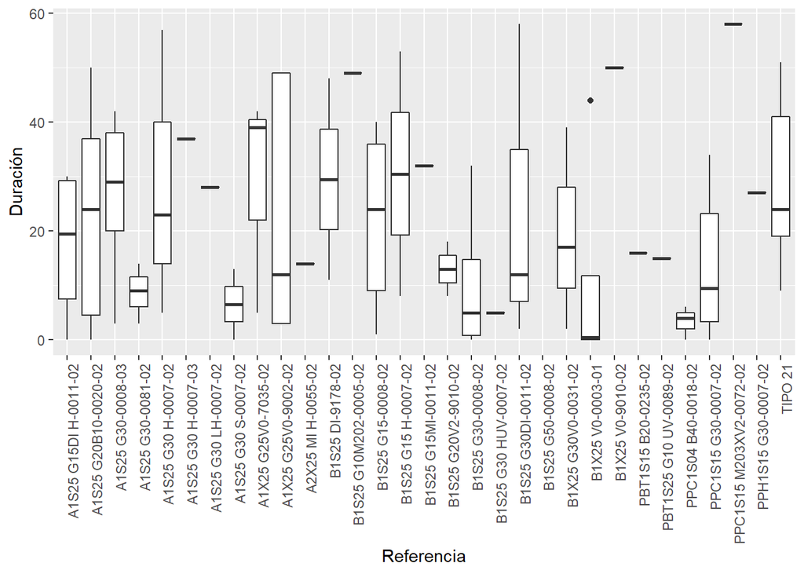

Podemos tambien realizar un boxplot para ver las duraciones medias de las averias y los tipos de averia:

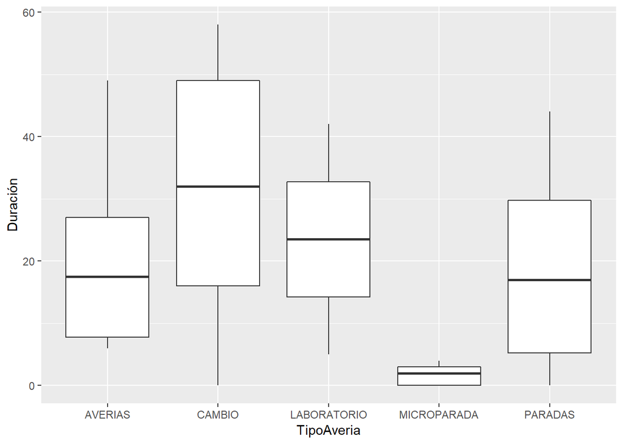

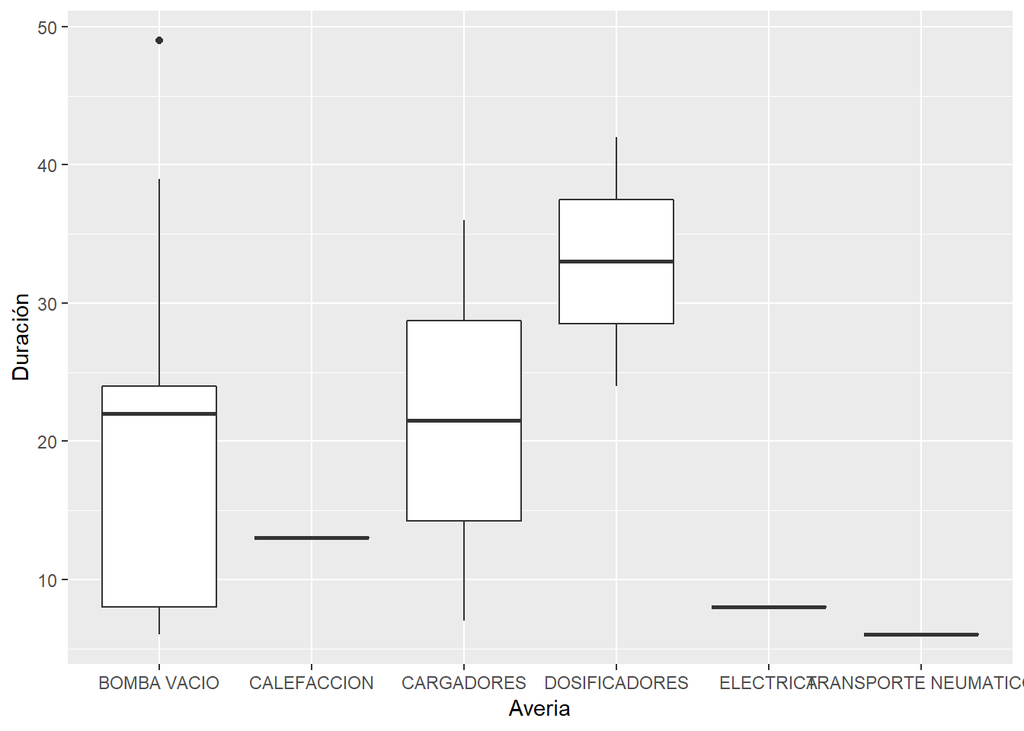

# Periodicidad del fichero de Averias

Vamos a estudiar ahora la periodicidad del fichero Averías.

Hemos tenido que transformar algunas de las diferencias temporales a horas, ya que así se especificaba en el enunciado.

Ahora realizamos las diferencias temporales para el conjunto de datos ds

```r
ds <- mutate(ds,difer.eventos=c(0,diff(Fecha_registro)))
```

Realizamos ahora la representación gráfica de la diferencia del la Fecha_registro y la diferencia de tiempos, para ver si podemos encontrar algún tipo de patrón.

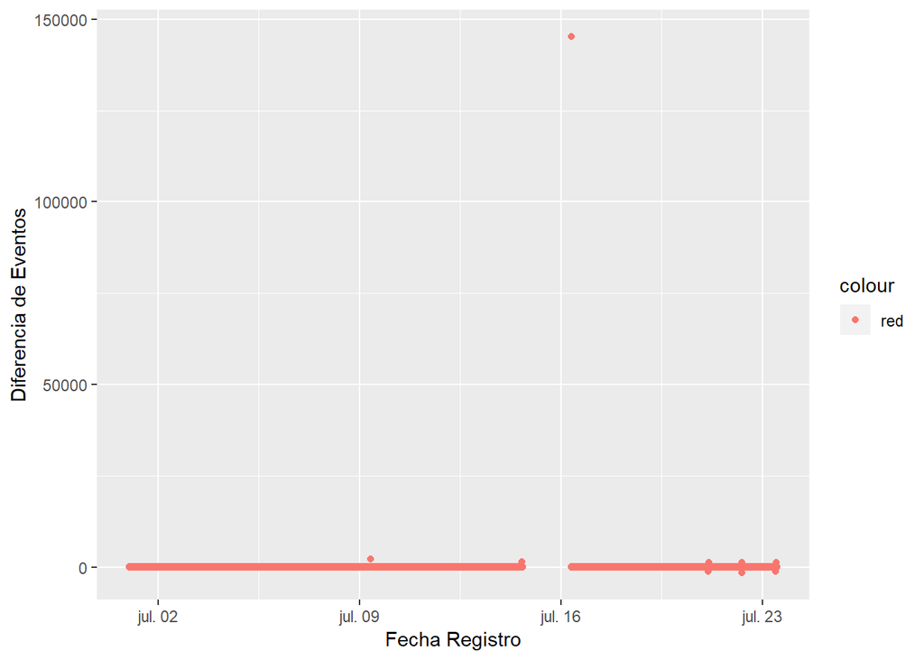

```r
library(ggplot2)
ggplot(ds,aes(ds$Fecha_registro,ds$difer.eventos,color="red"))+geom_point()+labs(x = "Fecha Registro", y = "Diferencia de Eventos")
```

Hemos encontrado que tenemos un posible outlayer para los valores de las diferencias temporales, a consecuencia de esto la escala con la que se ha representado no permite discernir ningún tipo de patrón. Procederé a representar la misma gráfica, limitando los valores representados en el eje y ,para ver si así podemos observar algún tipo de patrón.

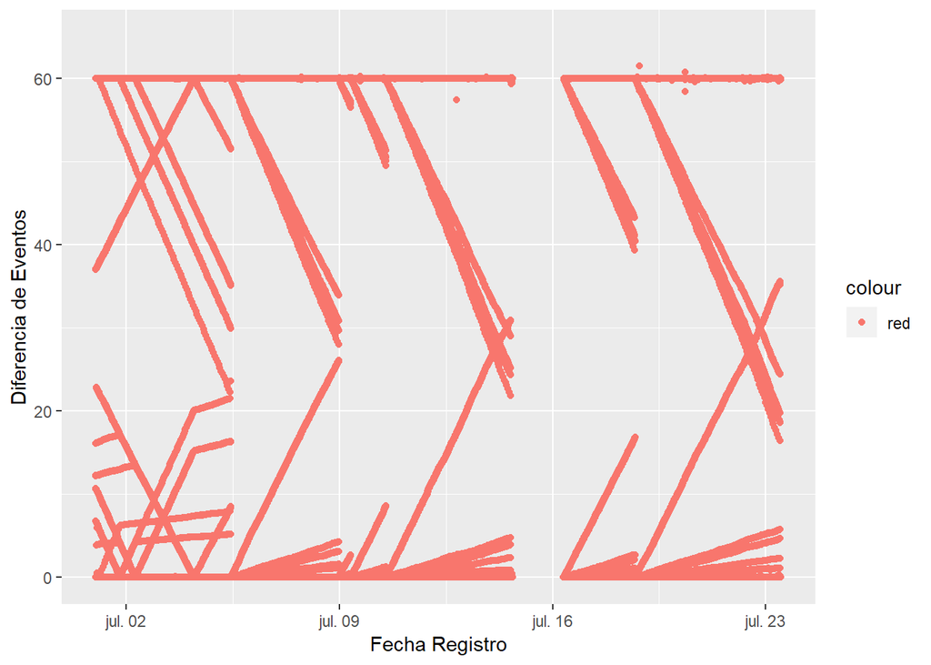

observamos así mismo que para diferentes días las diferencias tienen tanto regiones donde la diferencia temporal se mantiene constante en algunas regiones , no obstante a o largo del día también hay zonas donde la diferencias temporales decrecen y en crecen.

Vamos ahora a tomar el logaritmo en base 10 para transformar los valores de las diferencias de los eventos, con el fin de intentar observar algún patrón mas claro, que para las representaciones anteriores.

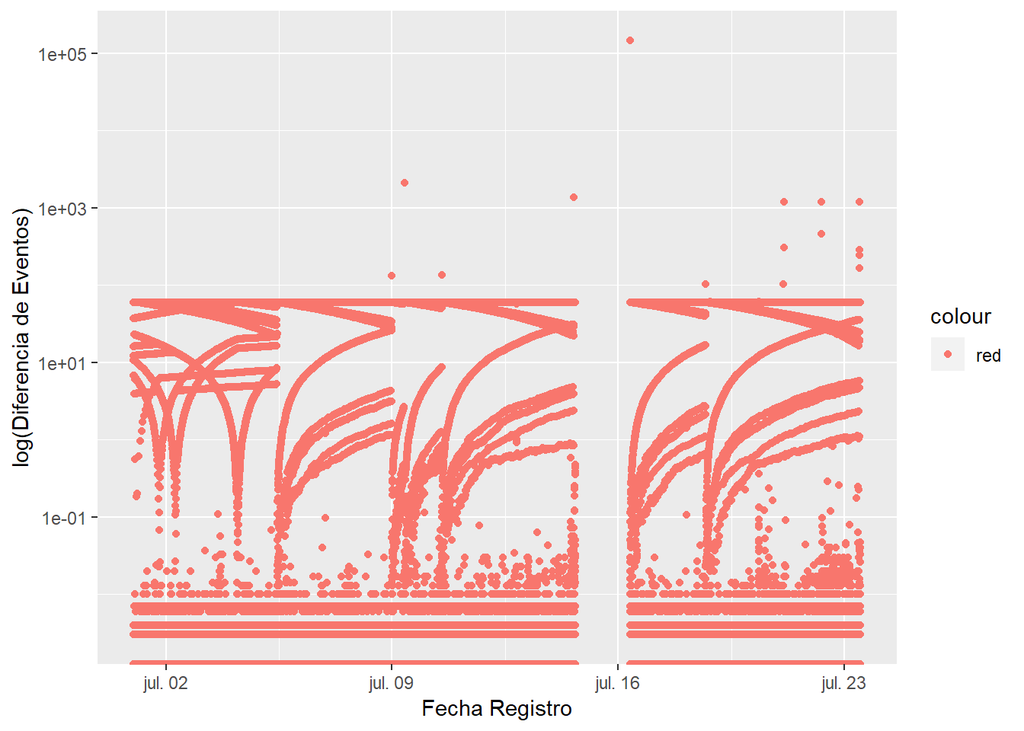

Observamos de nuevo un patrón, de nuevo los valores que podrían tratarse de outlayers nos modifican de forma importante la escala de representación, vamos a limitar de nuevo la escala, para ver la representación de forma mas detallada.

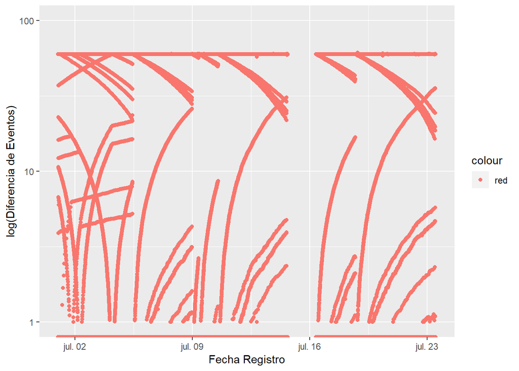

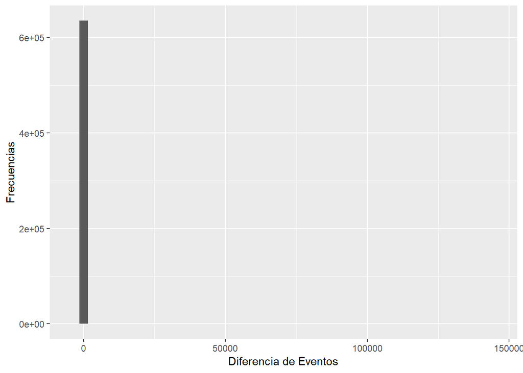

```r
ggplot(ds)+geom_histogram(aes(ds$difer.eventos),bins = 50)+labs(x = "Diferencia de Eventos", y = "Frecuencias")
```

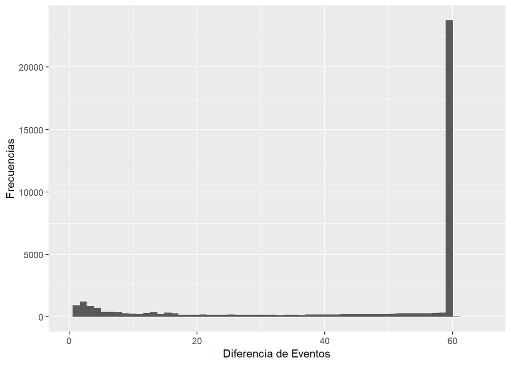

Creamos la nueva variable que contiene los tiempos de registro redondeados al minuto.

Seleccionamos ahora de forma aleatoria el 1% de los eventos de dataframe ds

```r
set.seed(3141592)
porc <- nrow(ds)*0.01 # para saber cuantas observaciones corresponderian al 1% del conjuto de datos
dsrand <- ds[sample(nrow(ds),porc),] # Seleccion del 1% de forma aleatoria del dataframe ds
```

Realizamos ahora el gráfico de la Id_variable frente a la Fecha_registro_Red

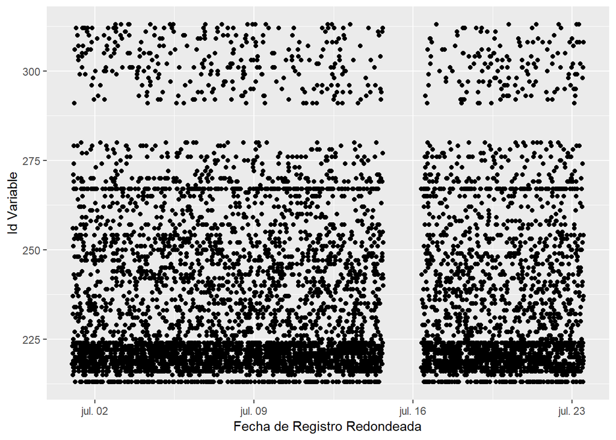

```r
ggplot(dsrand,aes(x=Fecha_registro_Red,y=ID_Variable))+geom_point()+labs(x = "Fecha de Registro Redondeada", y = "Id Variable")
```

Encontramos para el muestreo del 1% de los datos originales, una agrupación de puntos importante por debajo del valor de Id variable de 225, así como algunas franjas que por la agrupación de los puntos se asemejan a lineas rectas tanto para un Id Variable menor de 225 y otro cercano a 270. Así mismo encontramos que las alrededor de 16 de Julio, no tenemos muestreo de datos.

Realizamos ahora la misma gráfica, agrupando por colores para los distintos valores de la ID_variable.

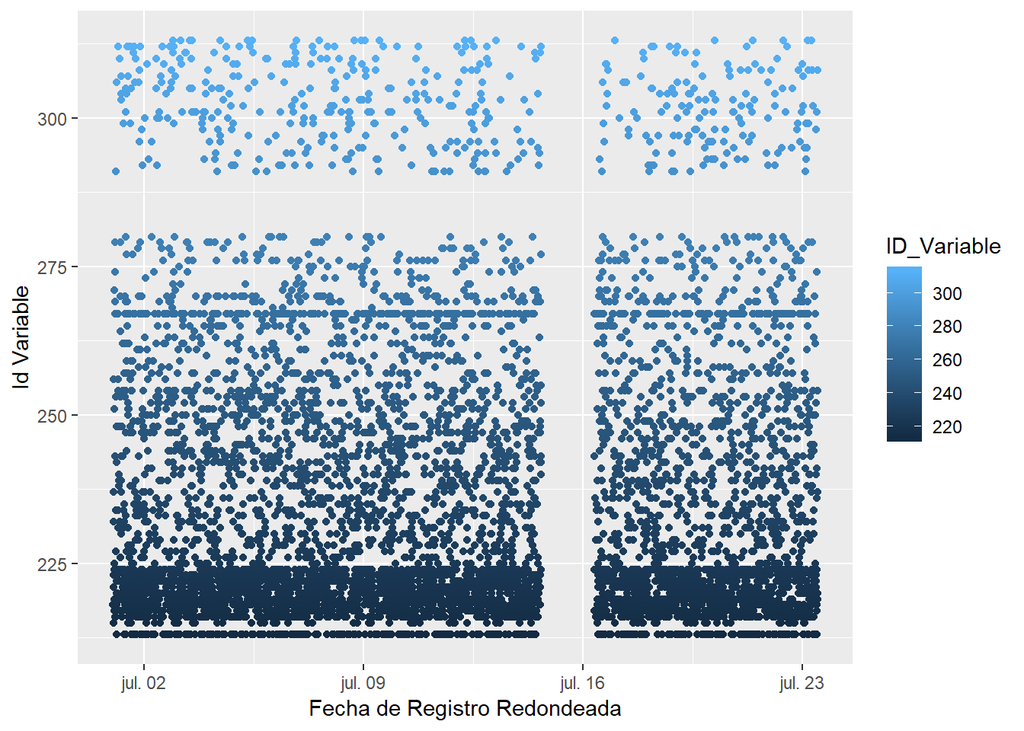

```r
ggplot(dsrand,aes(x=Fecha_registro_Red,y=ID_Variable,col=ID_Variable))+geom_point()+labs(x = "Fecha de Registro Redondeada", y = "Id Variable")
```

Se observa de nuevo, como tenemos una agrupación de puntos para el rango de 225, ya que se puede observar con el gradiente de colores obtenido al emplear la Id variable como color para los distintos puntos , un mayor numerario de zonas con azul color intenso que corresponde a aquellos valores por debajo de 225.

Realizamos un histograma para la Id_variable, para confirmar lo afirmado anteriormente.

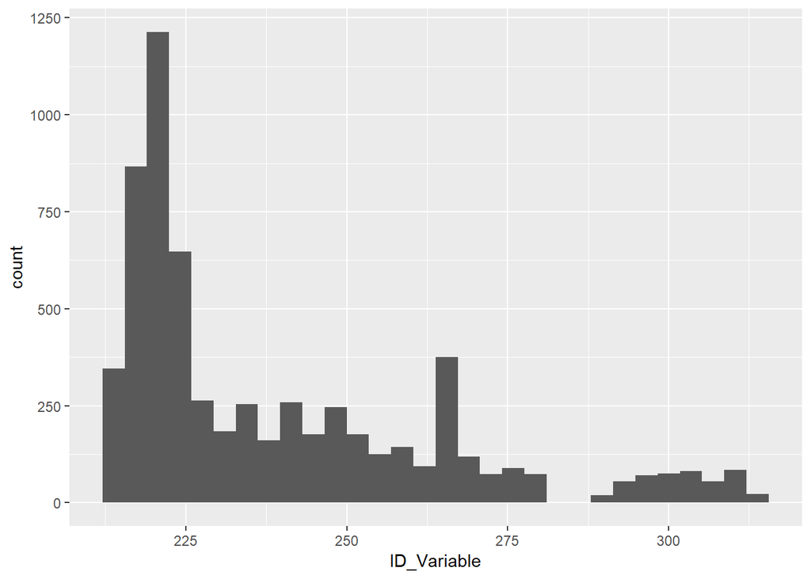

```r
ggplot(dsrand,aes(ID_Variable))+geom_histogram()
```

En efecto la mayor cantidad de valores estan agrupado por debajo de 225, así mismo cabe destacar que tenemos una región donde no hay valores para Id_Variable.

```r
rm(porc,dsrand)
```

# Grupos en Base a la frecuencia de muestreo.

```r
detach(package:dplyr)
detach(package:ggplot2)
library(dplyr)
RepEvento.ID_var <- ds %>% group_by(AR_Identificador) %>% summarise(rep=n())%>% arrange(desc(rep))
# empleamos el summarise para poder contar el numero de repeticiones con la instruccion n() de dplyr y el arrange para ordendar de forma descendiente para las repeticiones
```

```r
library(kableExtra)
Valmax <- RepEvento.ID_var %>% filter(rep==max(rep))

kable(Valmax,align = 'c') %>% kable_styling(bootstrap_options = c("striped", "hover", "condensed", "responsive","bordered"),full_width = F)
```

| AR_Identificador | rep |
| --- | --- |
| 0 SET POINT DOSIFICACIÓN A | 29910 |
| 106 TOTAL CAUDAL A DOSIFICAR | 29910 |
| 20 SET POINT DOSIFICACIÓN B | 29910 |
| 20 SET POINT DOSIFICACIÓN C | 29910 |
| 20 SET POINT DOSIFICACIÓN D | 29910 |
| 20 SET POINT DOSIFICACIÓN E | 29910 |
| 78 DOSIFICACIÓN B | 29910 |
| 78 DOSIFICACIÓN C | 29910 |
| 78 DOSIFICACIÓN D | 29910 |
| 78 DOSIFICACIÓN E | 29910 |
| 78 Dosificador A | 29910 |

En la tabla anterior se refleja las variables con las mayores frecuencias de muestreo.

Para ver si tiene relación las variables con mayor muestro con la ID_variable, realizamos una selección de los valores de ds que contienen el AR_identificador de aquellas muestras que tienen el mayor numero de cuentas y realizamos un histograma de los valores para ID_Variable.

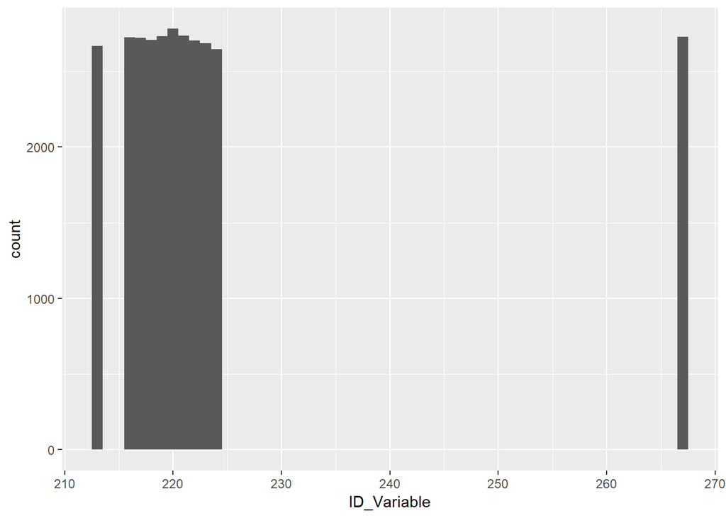

```r
library(ggplot2)
ggplot(ID_varrel,aes(ID_Variable))+geom_histogram(binwidth = 1)
```

```r
rm(ID_varrel)
```

Como se puede ver de nuevo, aquellas variables que tienen mayor frecuencia , poseen al mismo tiempo valores de ID_variable alrededor de 220, como en los casos anteriores ya estudiados.

```r
cat('Las repeticiones diferentes que tenemos seran:',unique(RepEvento.ID_var$rep))
```

```
## Las repeticiones diferentes que tenemos seran: 29910 5987 2996 2000 505
```

De esta forma suponemos que ahora debemos asignar las etiquetas para los 5 periodos que se han obtenido al medir las repeticiones, donde 01 se asignara a las variables con repetición 29910, 05 a las que tengan repetición 5987 y así para el resto.

```r
#Para crear la nueva variable que meteremos en el dataframe RepEvento.Id
et <- as.character()
for (i in seq(nrow(RepEvento.ID_var))){

  if(RepEvento.ID_var$rep[i]==29910)
    et <- c(et,'01')
  if(RepEvento.ID_var$rep[i]==5987)
    et<- c(et,'05')
  if(RepEvento.ID_var$rep[i]==2996)
    et<- c(et,'10')
  if(RepEvento.ID_var$rep[i]==2000)
    et<- c(et,'15')
  if(RepEvento.ID_var$rep[i]==505)
    et<- c(et,'60')
}
et <- as.factor(et)
```

```r
RepEvento.ID_var <- mutate(RepEvento.ID_var,nfac=et)
kable(head(RepEvento.ID_var),align = 'c') %>% kable_styling(bootstrap_options = c("striped", "hover", "condensed", "responsive","bordered"),full_width = F)
```

| AR_Identificador | rep | nfac |
| --- | --- | --- |
| 0 SET POINT DOSIFICACIÓN A | 29910 | 01 |
| 106 TOTAL CAUDAL A DOSIFICAR | 29910 | 01 |
| 20 SET POINT DOSIFICACIÓN B | 29910 | 01 |
| 20 SET POINT DOSIFICACIÓN C | 29910 | 01 |
| 20 SET POINT DOSIFICACIÓN D | 29910 | 01 |
| 20 SET POINT DOSIFICACIÓN E | 29910 | 01 |

```r
rm(RepEvento.ID_var)
```

Se puede ver que se ha creado correctamente la nueva columna del dataframe y se ha guardado la variable nfac como factor.

Crearemos ahora una nueva variable para el dataframe ds , que combinara la periodicidad y las variables, para ello primero agruparemos los datos.

```r
datainter <- ds %>% group_by(ID_Variable,AR_Identificador) %>% summarise(rep=n())
```

```r
#Para crear la nueva variable que meteremos en el dataframe RepEvento.Id
et <- as.character()
for (i in seq(nrow(datainter))){

  if(datainter$rep[i]==29910)
    et <- c(et,'01')
  if(datainter$rep[i]==5987)
    et<- c(et,'05')
  if(datainter$rep[i]==2996)
    et<- c(et,'10')
  if(datainter$rep[i]==2000)
    et<- c(et,'15')
  if(datainter$rep[i]==505)
    et<- c(et,'60')
}
et <- as.factor(et)
```

```r
datainter$nafc <- et
kable(head(datainter)
,align = 'c') %>% kable_styling(bootstrap_options = c("striped", "hover", "condensed", "responsive","bordered"),full_width = F)
```

| ID_Variable | AR_Identificador | rep | nafc |
| --- | --- | --- | --- |
| 213 | 78 Dosificador A | 29910 | 01 |
| 215 | Entrada Vacuometro | 5987 | 05 |
| 216 | 0 SET POINT DOSIFICACIÓN A | 29910 | 01 |
| 217 | 78 DOSIFICACIÓN B | 29910 | 01 |
| 218 | 20 SET POINT DOSIFICACIÓN B | 29910 | 01 |
| 219 | 78 DOSIFICACIÓN C | 29910 | 01 |

```r
library(tidyr)
dsinterm <- merge(ds,datainter,sort = F)
t <- rep("t",635023)
dsinterm$t <- t
dsinnuevo <- unite(dsinterm,"intter",c(t,nafc),sep="") #Al unir nos desaparecen las columnas que combinamos, de esta forma , será necesario guardar el valor de ds$ID_variable, antes de unir las columans en su forma final, de esta forma.


dsinnuevo1 <- unite(dsinnuevo,"ID_Variable_per",c(intter,ID_Variable),sep=".")
dsinnuevo1$ID_Variable <- ds$ID_Variable
dsinnuevo1$ID_Variable_per <- as.factor(dsinnuevo1$ID_Variable_per)

#Ahora guardamos el dataframe en el dataframe que teniamos origalmente.

ds <- dsinnuevo1
```

```r
#eliminamos los dataframes y varaibles intermedias empleadas hasta el momento, para liberar memoria y porque dudo que las pueda emplear de nuevo

rm(dsinnuevo,dsinnuevo1,i,et,Valmax,dsinterm,t,datainter)
```

# Analisis de las varaibles medidas en ds

Tras realizar esto guardaremos el resultado un nuevo dataframe llamado ds.nz, donde guardamos las variables del dataframe ds que no contienen valores nulos y que nos aportan algo de información. Se ha cambado también los valores de la variable Valor de carácter a numérico, considerando que el separador de decimales en dicha variable inicialmente estaba con una coma en lugar de como un punto. Esto es importante, ya que si no se considera esto, se puede obtener una variable distinta a la esperada.

Creamos un nuevo dataset llamado ds.nz.col

```r
ds.nz.col <- spread(ds.nz,ID_Variable_per,Valor)

# Comprobamos si los valores contenidos son los mismos en el dataaframe separado que en el original
sum(select(ds.nz.col,-(1:8)),na.rm=T)==sum(ds.nz$Valor)
```

```
## [1] TRUE
```

Creamos el dataframe llamado data partiendo del dataframe ds.nz.col

```r
#Diria que asi esta bien, los enuncuados estan demasiado confusos
data <- gather(ds.nz.col,Variable,Valor,-c(1:8))
data <- data[complete.cases(data[,-4]),]
data <- select(data,Fecha_registro_Red,Variable,Valor)
```

# Analisis visual de ds

Suponemos que se refiere que a las variables se refiere a la columna ID_Variable_per de ds y hacemos la media para dicho dataframe.

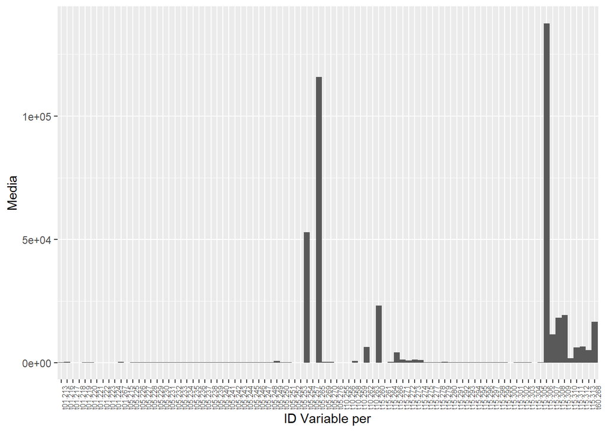

```r
ds$Valor <- ds$Valor %>% retype()
datosmedias <- ds %>% group_by(ID_Variable_per) %>% summarise(media= mean(Valor))


ggplot(datosmedias,aes(ID_Variable_per,media))+geom_bar(width = 1, stat='identity')+theme(axis.text.x = element_text(angle = 90,size=6) )+labs(x = "ID Variable per", y = "Media")
```

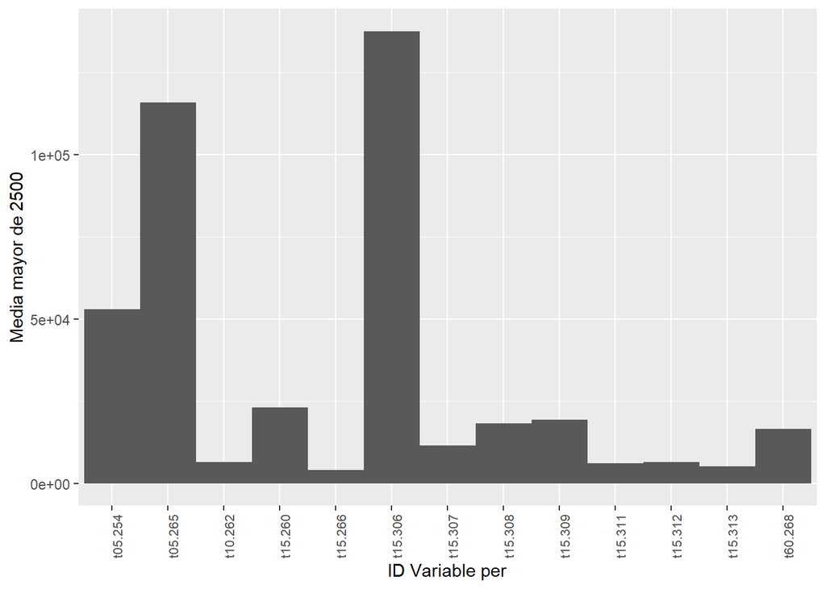

```r
ggplot(filter(datosmedias,media>2500),aes(ID_Variable_per,media))+geom_bar(width = 1, stat='identity')+theme(axis.text.x = element_text(angle = 90,size=8) )+labs(x = "ID Variable per", y = "Media mayor de 2500")
```

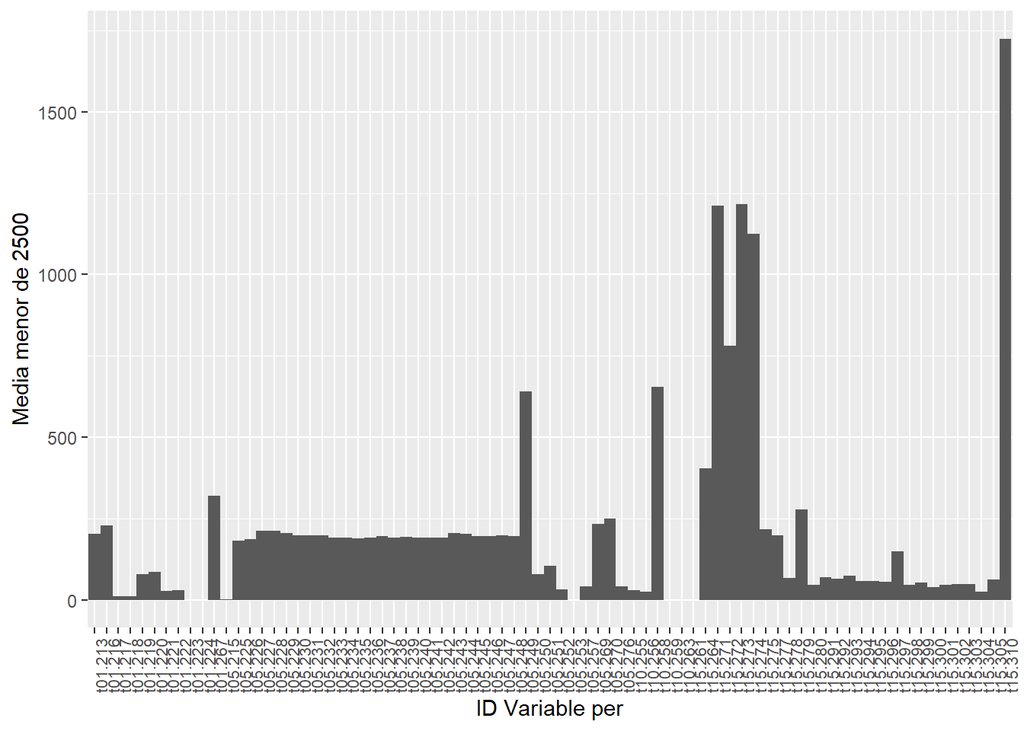

```r
ggplot(filter(datosmedias,media<2500),aes(ID_Variable_per,media))+geom_bar(width = 1, stat='identity')+theme(axis.text.x = element_text(angle = 90,size=8) )+labs(x = "ID Variable per", y = "Media menor de 2500")
```

Queremos ahora conocer la información sobre la distribución de la variables, de esta forma queremos realizar un boxplot en función de la periodicidad creando un boxplot para cada grupo de variables.

```r
data.group <- data %>% separate(Variable,c("periodo","ID_Variable"))
data.group$periodo <- as.factor(gsub("t", "", paste(data.group$periodo))) #para eliminar las t's de los periodos y lo hacemos factor.

data.group$ID_Variable <- as.numeric(data.group$ID_Variable)
```

Realizamos ahora la representación con ggplot empleando la instrucción facet_grid.

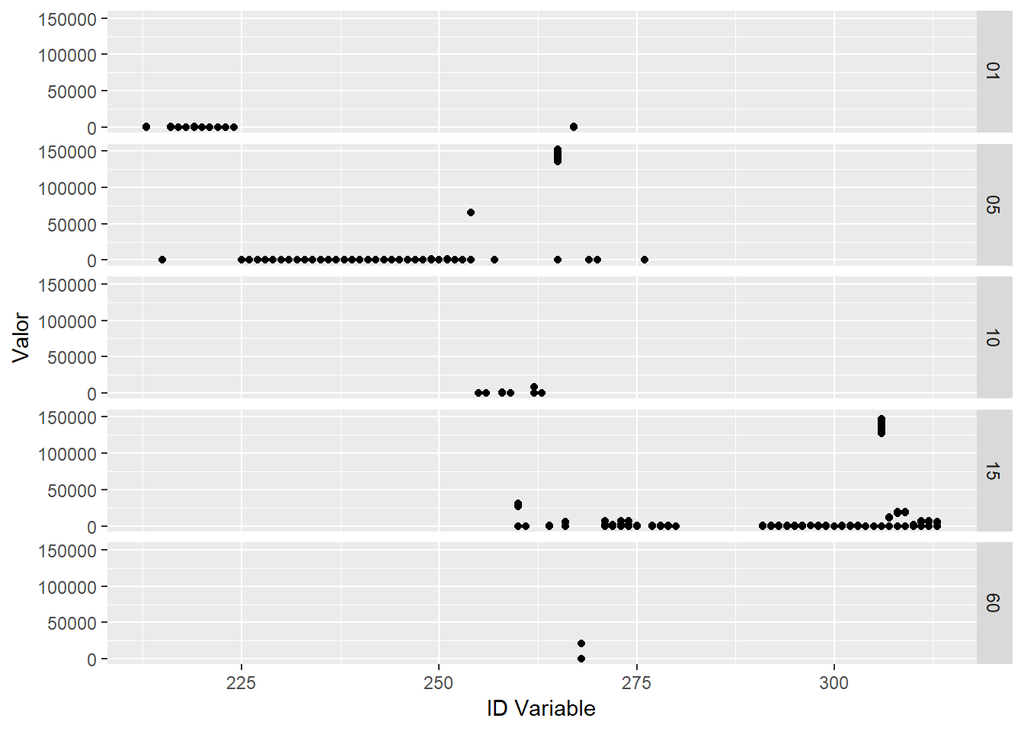

```r
ggplot(data.group,aes(ID_Variable,Valor),color=periodo)+geom_point()+facet_grid(rows = vars(periodo))+labs(x = "ID Variable", y = "Valor")
```

En la gráfica anterior podemos ver los puntos agrupados por periodo y representando el ID_Variable frente al Valor. Vamos ahora a realizar el boxplot, para ver que se nos muestra.

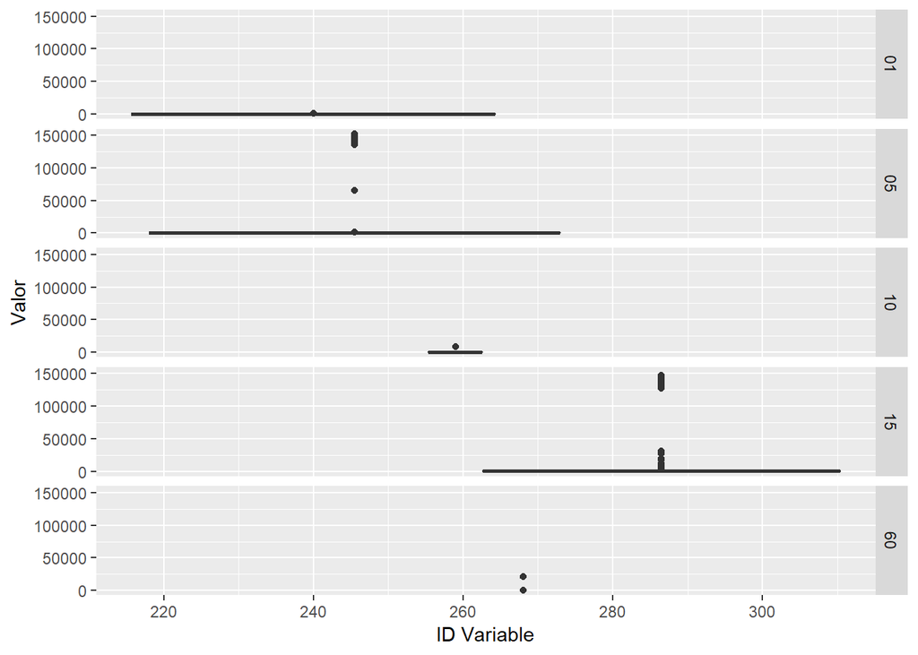

Debido a las diferencias de escalas vamos a representar para los diferentes periodos por separado.

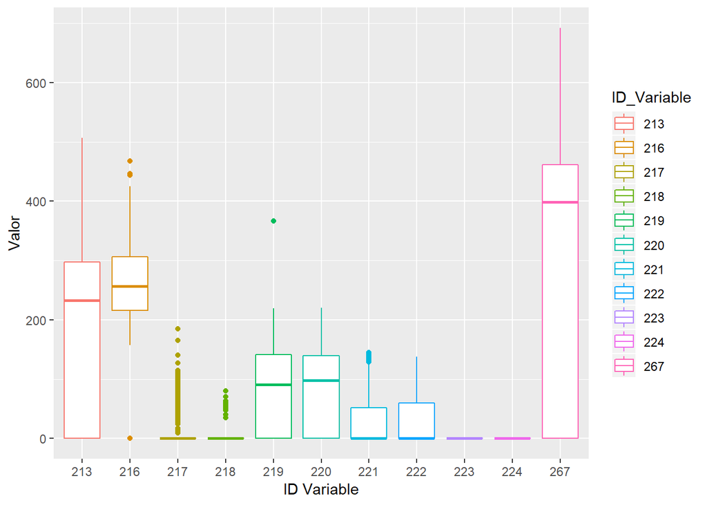

```r
grupo01 <- filter(data.group,periodo=="01")
grupo01$ID_Variable <- as.factor(grupo01$ID_Variable)
ggplot(grupo01,aes(ID_Variable,Valor,col=ID_Variable))+geom_boxplot()+labs(x = "ID Variable", y = "Valor")
```

Cabe destacar que nos quedan para varias ID algo no apreciable, esto no se debe a la escala, sino a que contiene tantas cantidades de ceros que la media queda en cero.

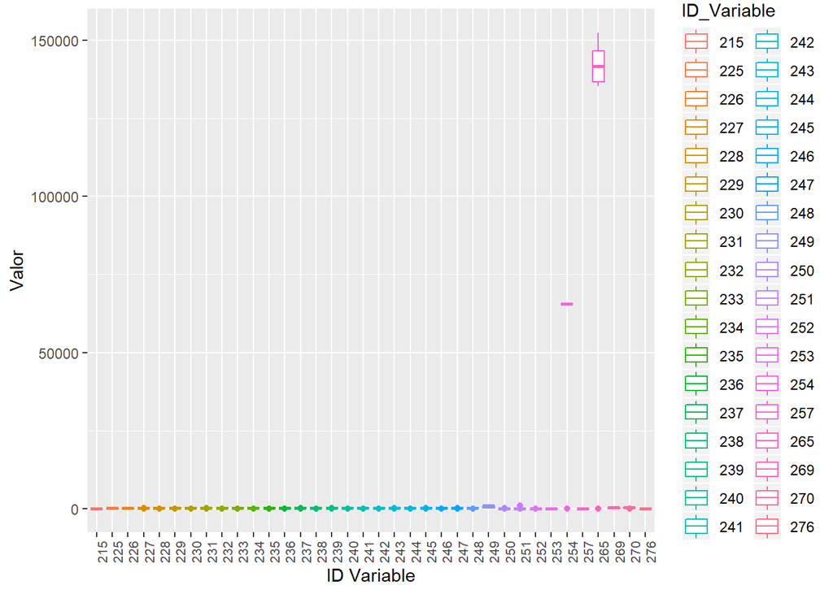

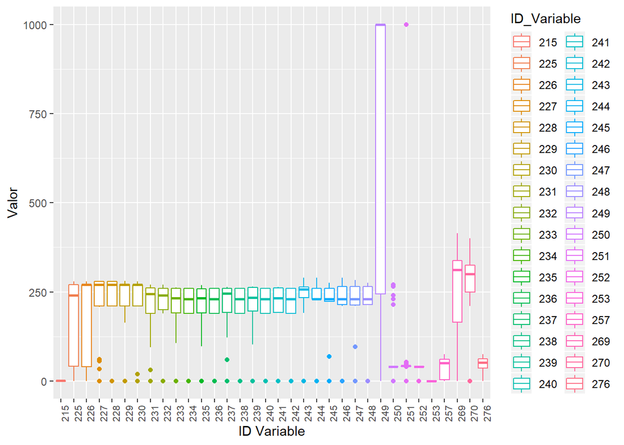

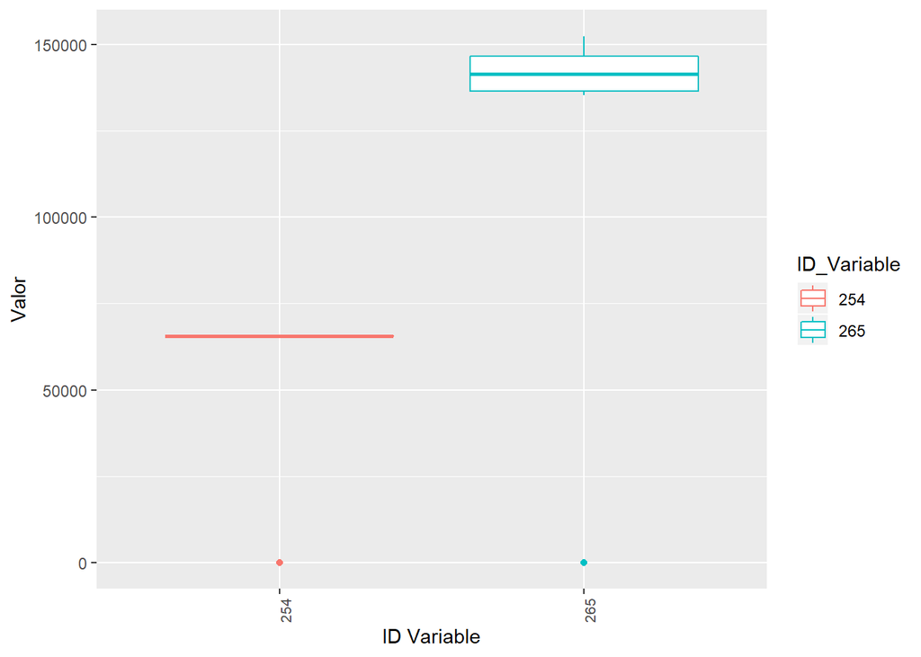

De nuevo en este caso tenemos sobre todo valores con medias muy centradas en cero, esto es mucho mas aparente en la primera de las gráficas.

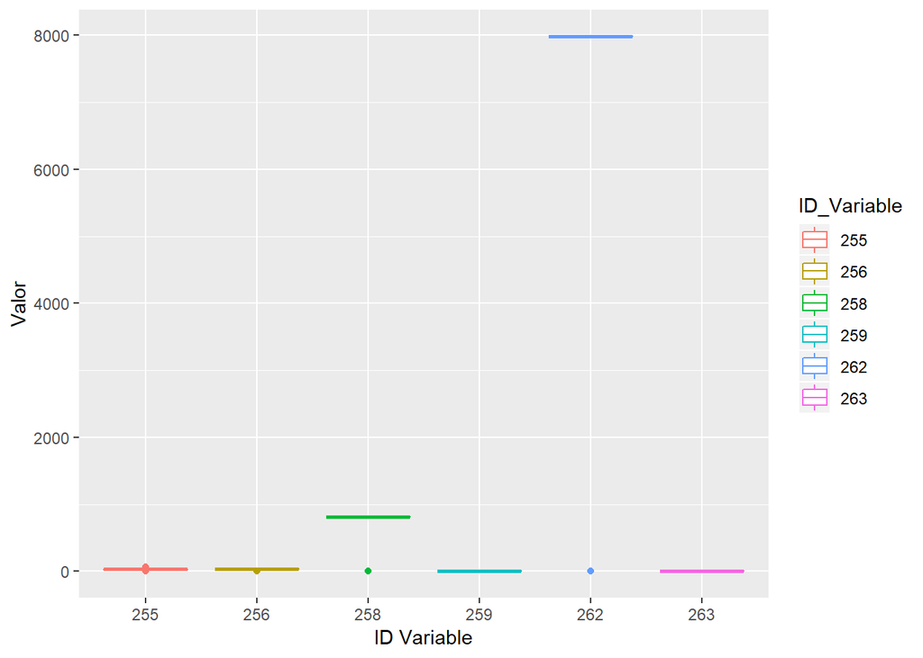

```r
grupo10 <- filter(data.group,periodo=="10")
grupo10$ID_Variable <- as.factor(grupo10$ID_Variable)
ggplot(grupo10,aes(ID_Variable,Valor,col=ID_Variable))+geom_boxplot()+labs(x = "ID Variable", y = "Valor")
```

De nuevo como en el caso anterior casi todos los valores nos salen centrados en cero, salvo en el caso de valor de ID Variable de 258 y 262.

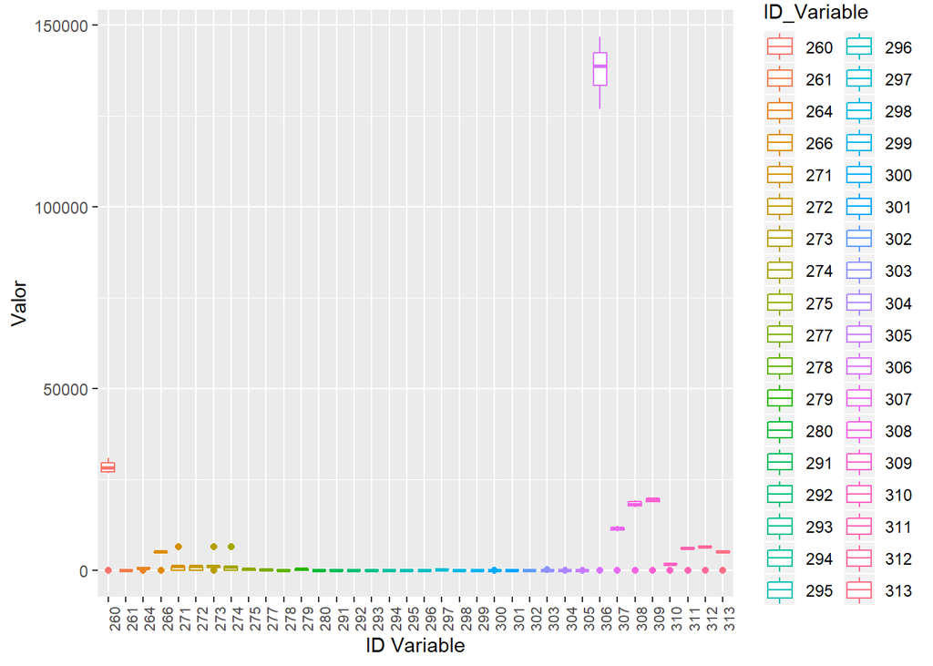

```r
grupo15 <- filter(data.group,periodo=="15")
grupo15$ID_Variable <- as.factor(grupo15$ID_Variable)
ggplot(grupo15,aes(ID_Variable,Valor,col=ID_Variable))+geom_boxplot()+labs(x = "ID Variable", y = "Valor")+theme(axis.text.x = element_text(angle = 90,size=8) )
```

De nuevo la mayoría de valores tiene media cero, por eso no son apreciables en los boxplots.

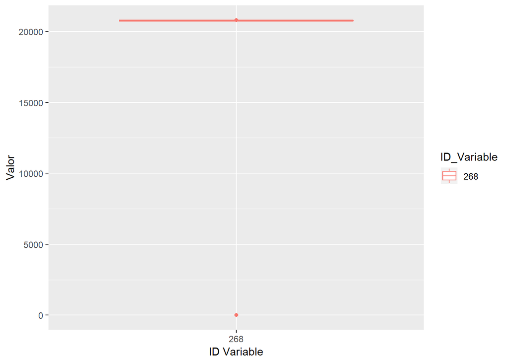

```r
grupo60 <- filter(data.group,periodo==60)
grupo60$ID_Variable <- as.factor(grupo60$ID_Variable)
ggplot(grupo60,aes(ID_Variable,Valor,col=ID_Variable))+geom_boxplot()+labs(x = "ID Variable", y = "Valor")
```

```r
#eliminamos los dataframes de grupos, ya que no se usaran mas adelante
rm(grupo01,grupo05parc2,grupo05,grupo05parc,grupo10,grupo15,grupo60,data.group)
```

# Analisis estadistico de ds.nz

```r
library(mlr)
ds.nzfi <- select(ds.nz,-ID_Variable_per,-AR_Identificador,-Fecha_registro,-Fecha_registro_Red)
ds.nz2 <- select(summarizeColumns(ds.nzfi),-na,-mad,-nlevs,-type)

names(ds.nz2) <- c("Variable","Media","Desviación típica","Mediana","Mínimo","Máximo")

kable(ds.nz2,digits=2,caption = "Descripción de las variables")
```

Descripción de las variables

| Variable | Media | Desviación típica | Mediana | Mínimo | Máximo |
| --- | --- | --- | --- | --- | --- |
| Reg_variable | 3.083986e+06 | 1.833155e+05 | 3.083986e+06 | 2.766475e+06 | 3.401497e+06 |
| Valor | 2.496340e+03 | 1.578249e+04 | 5.990000e+01 | 0.000000e+00 | 1.524044e+05 |
| TRAZ_Id_Reg_Maquina | 6.366695e+14 | 5.776529e+09 | 6.366690e+14 | 6.366600e+14 | 6.366794e+14 |
| difer.eventos | 3.060000e+00 | 1.827100e+02 | 0.000000e+00 | -1.654440e+03 | 1.452158e+05 |
| rep | 1.784060e+04 | 1.257338e+04 | 2.991000e+04 | 5.050000e+02 | 2.991000e+04 |
| ID_Variable | 2.387700e+02 | 2.528000e+01 | 2.270000e+02 | 2.130000e+02 | 3.130000e+02 |

# Analisis del fichero alarmas.

Vamos a determinar los productos plásticos que mas se fabrican, para ello vamos a obtener la frecuencia de aparición de los diferentes tipo de plásticos.

| Referencia | rep |
| --- | --- |
| B1S25 G15-0008-02 | 13 |
| PPC1S15 G30-0007-02 | 8 |
| A1S25 G20B10-0020-02 | 7 |
| A1S25 G30-0008-03 | 5 |
| A1X25 G25V0-9002-02 | 5 |
| B1S25 G30-0008-02 | 5 |
| TIPO 21 | 5 |
| A1S25 G15DI H-0011-02 | 4 |
| B1X25 V0-0003-01 | 4 |
| A1S25 G30-0081-02 | 3 |
| A1S25 G30 H-0007-02 | 3 |
| A1X25 G25V0-7035-02 | 3 |
| B1S25 G30DI-0011-02 | 3 |
| B1X25 G30V0-0031-02 | 3 |
| PPC1S04 B40-0018-02 | 3 |
| A1S25 G30 S-0007-02 | 2 |
| B1S25 DI-9178-02 | 2 |
| B1S25 G15 H-0007-02 | 2 |
| B1S25 G20V2-9010-02 | 2 |
| A1S25 G30 H-0007-03 | 1 |
| A1S25 G30 LH-0007-02 | 1 |
| A2X25 MI H-0055-02 | 1 |
| B1S25 G10M202-0005-02 | 1 |
| B1S25 G15MI-0011-02 | 1 |
| B1S25 G30 HUV-0007-02 | 1 |
| B1S25 G50-0008-02 | 1 |
| B1X25 V0-9010-02 | 1 |
| PBT1S15 B20-0235-02 | 1 |
| PBT1S25 G10 UV-0089-02 | 1 |
| PPC1S15 M203XV2-0072-02 | 1 |
| PPH1S15 G30-0007-02 | 1 |

Las referencias con mayores frecuencias son B1S25 G15-008-02 , PPC1S15 G30-007-02 y A1S25 G20B10-0020-02.

## Tipos de alarma frente al tipo de plastico fabricado.

Creamos la tabla de contingencia para los tipos de alarma frente a los plásticos fabricados.

```r
Plastico.Tipo.Averia <-table(daver$Referencia,daver$TipoAveria)



 kable(Plastico.Tipo.Averia,align = 'c') %>% kable_styling(bootstrap_options = c("striped", "hover", "condensed", "responsive","bordered"))
```

AVERIAS

CAMBIO

LABORATORIO

MICROPARADA

PARADAS

A1S25 G15DI H-0011-02

0

0

1

0

1

2

A1S25 G20B10-0020-02

0

2

1

0

2

2

A1S25 G30-0008-03

0

1

2

0

0

2

A1S25 G30-0081-02

0

0

2

0

1

0

A1S25 G30 H-0007-02

0

0

2

0

0

1

A1S25 G30 H-0007-03

0

0

0

0

0

1

A1S25 G30 LH-0007-02

0

0

0

0

0

1

A1S25 G30 S-0007-02

0

0

1

0

0

1

A1X25 G25V0-7035-02

0

0

1

2

0

0

A1X25 G25V0-9002-02

0

2

1

0

2

0

A2X25 MI H-0055-02

0

0

0

0

0

1

B1S25 DI-9178-02

0

0

1

0

0

1

B1S25 G10M202-0005-02

0

0

1

0

0

0

B1S25 G15-0008-02

0

5

2

0

1

5

B1S25 G15 H-0007-02

0

1

1

0

0

0

B1S25 G15MI-0011-02

0

0

1

0

0

0

B1S25 G20V2-9010-02

0

1

1

0

0

0

B1S25 G30-0008-02

1

0

1

0

1

2

B1S25 G30 HUV-0007-02

0

0

0

0

0

1

B1S25 G30DI-0011-02

0

0

2

0

1

0

B1S25 G50-0008-02

1

0

0

0

0

0

B1X25 G30V0-0031-02

0

0

1

0

1

1

B1X25 V0-0003-01

0

0

0

0

2

2

B1X25 V0-9010-02

0

0

1

0

0

0

PBT1S15 B20-0235-02

0

0

1

0

0

0

PBT1S25 G10 UV-0089-02

0

0

1

0

0

0

PPC1S04 B40-0018-02

0

1

1

0

1

0

PPC1S15 G30-0007-02

0

2

1

0

2

3

PPC1S15 M203XV2-0072-02

0

0

1

0

0

0

PPH1S15 G30-0007-02

0

0

1

0

0

0

TIPO 21

0

1

4

0

0

0

Añadimos a el dataframe anterior las frecuencias absolutas y lo mostramos:

Referencia

Tipo Averia

Frecuencia

Frecuencia Absoluta

A1S25 G15DI H-0011-02

0

4

A1S25 G20B10-0020-02

0

7

A1S25 G30-0008-03

0

5

A1S25 G30-0081-02

0

3

A1S25 G30 H-0007-02

0

3

A1S25 G30 H-0007-03

0

1

A1S25 G30 LH-0007-02

0

1

A1S25 G30 S-0007-02

0

2

A1X25 G25V0-7035-02

0

3

A1X25 G25V0-9002-02

0

5

A2X25 MI H-0055-02

0

1

B1S25 DI-9178-02

0

2

B1S25 G10M202-0005-02

0

1

B1S25 G15-0008-02

0

13

B1S25 G15 H-0007-02

0

2

B1S25 G15MI-0011-02

0

1

B1S25 G20V2-9010-02

0

2

B1S25 G30-0008-02

1

5

B1S25 G30 HUV-0007-02

0

1

B1S25 G30DI-0011-02

0

3

B1S25 G50-0008-02

1

1

B1X25 G30V0-0031-02

0

3

B1X25 V0-0003-01

0

4

B1X25 V0-9010-02

0

1

PBT1S15 B20-0235-02

0

1

PBT1S25 G10 UV-0089-02

0

1

PPC1S04 B40-0018-02

0

3

PPC1S15 G30-0007-02

0

8

PPC1S15 M203XV2-0072-02

0

1

PPH1S15 G30-0007-02

0

1

TIPO 21

0

5

A1S25 G15DI H-0011-02

AVERIAS

0

4

A1S25 G20B10-0020-02

AVERIAS

2

7

A1S25 G30-0008-03

AVERIAS

1

5

A1S25 G30-0081-02

AVERIAS

0

3

A1S25 G30 H-0007-02

AVERIAS

0

3

A1S25 G30 H-0007-03

AVERIAS

0

1

A1S25 G30 LH-0007-02

AVERIAS

0

1

A1S25 G30 S-0007-02

AVERIAS

0

2

A1X25 G25V0-7035-02

AVERIAS

0

3

A1X25 G25V0-9002-02

AVERIAS

2

5

A2X25 MI H-0055-02

AVERIAS

0

1

B1S25 DI-9178-02

AVERIAS

0

2

B1S25 G10M202-0005-02

AVERIAS

0

1

B1S25 G15-0008-02

AVERIAS

5

13

B1S25 G15 H-0007-02

AVERIAS

1

2

B1S25 G15MI-0011-02

AVERIAS

0

1

B1S25 G20V2-9010-02

AVERIAS

1

2

B1S25 G30-0008-02

AVERIAS

0

5

B1S25 G30 HUV-0007-02

AVERIAS

0

1

B1S25 G30DI-0011-02

AVERIAS

0

3

B1S25 G50-0008-02

AVERIAS

0

1

B1X25 G30V0-0031-02

AVERIAS

0

3

B1X25 V0-0003-01

AVERIAS

0

4

B1X25 V0-9010-02

AVERIAS

0

1

PBT1S15 B20-0235-02

AVERIAS

0

1

PBT1S25 G10 UV-0089-02

AVERIAS

0

1

PPC1S04 B40-0018-02

AVERIAS

1

3

PPC1S15 G30-0007-02

AVERIAS

2

8

PPC1S15 M203XV2-0072-02

AVERIAS

0

1

PPH1S15 G30-0007-02

AVERIAS

0

1

TIPO 21

AVERIAS

1

5

A1S25 G15DI H-0011-02

CAMBIO

1

4

A1S25 G20B10-0020-02

CAMBIO

1

7

A1S25 G30-0008-03

CAMBIO

2

5

A1S25 G30-0081-02

CAMBIO

2

3

A1S25 G30 H-0007-02

CAMBIO

2

3

A1S25 G30 H-0007-03

CAMBIO

0

1

A1S25 G30 LH-0007-02

CAMBIO

0

1

A1S25 G30 S-0007-02

CAMBIO

1

2

A1X25 G25V0-7035-02

CAMBIO

1

3

A1X25 G25V0-9002-02

CAMBIO

1

5

A2X25 MI H-0055-02

CAMBIO

0

1

B1S25 DI-9178-02

CAMBIO

1

2

B1S25 G10M202-0005-02

CAMBIO

1

1

B1S25 G15-0008-02

CAMBIO

2

13

B1S25 G15 H-0007-02

CAMBIO

1

2

B1S25 G15MI-0011-02

CAMBIO

1

1

B1S25 G20V2-9010-02

CAMBIO

1

2

B1S25 G30-0008-02

CAMBIO

1

5

B1S25 G30 HUV-0007-02

CAMBIO

0

1

B1S25 G30DI-0011-02

CAMBIO

2

3

B1S25 G50-0008-02

CAMBIO

0

1

B1X25 G30V0-0031-02

CAMBIO

1

3

B1X25 V0-0003-01

CAMBIO

0

4

B1X25 V0-9010-02

CAMBIO

1

1

PBT1S15 B20-0235-02

CAMBIO

1

1

PBT1S25 G10 UV-0089-02

CAMBIO

1

1

PPC1S04 B40-0018-02

CAMBIO

1

3

PPC1S15 G30-0007-02

CAMBIO

1

8

PPC1S15 M203XV2-0072-02

CAMBIO

1

1

PPH1S15 G30-0007-02

CAMBIO

1

1

TIPO 21

CAMBIO

4

5

A1S25 G15DI H-0011-02

LABORATORIO

0

4

A1S25 G20B10-0020-02

LABORATORIO

0

7

A1S25 G30-0008-03

LABORATORIO

0

5

A1S25 G30-0081-02

LABORATORIO

0

3

A1S25 G30 H-0007-02

LABORATORIO

0

3

A1S25 G30 H-0007-03

LABORATORIO

0

1

A1S25 G30 LH-0007-02

LABORATORIO

0

1

A1S25 G30 S-0007-02

LABORATORIO

0

2

A1X25 G25V0-7035-02

LABORATORIO

2

3

A1X25 G25V0-9002-02

LABORATORIO

0

5

A2X25 MI H-0055-02

LABORATORIO

0

1

B1S25 DI-9178-02

LABORATORIO

0

2

B1S25 G10M202-0005-02

LABORATORIO

0

1

B1S25 G15-0008-02

LABORATORIO

0

13

B1S25 G15 H-0007-02

LABORATORIO

0

2

B1S25 G15MI-0011-02

LABORATORIO

0

1

B1S25 G20V2-9010-02

LABORATORIO

0

2

B1S25 G30-0008-02

LABORATORIO

0

5

B1S25 G30 HUV-0007-02

LABORATORIO

0

1

B1S25 G30DI-0011-02

LABORATORIO

0

3

B1S25 G50-0008-02

LABORATORIO

0

1

B1X25 G30V0-0031-02

LABORATORIO

0

3

B1X25 V0-0003-01

LABORATORIO

0

4

B1X25 V0-9010-02

LABORATORIO

0

1

PBT1S15 B20-0235-02

LABORATORIO

0

1

PBT1S25 G10 UV-0089-02

LABORATORIO

0

1

PPC1S04 B40-0018-02

LABORATORIO

0

3

PPC1S15 G30-0007-02

LABORATORIO

0

8

PPC1S15 M203XV2-0072-02

LABORATORIO

0

1

PPH1S15 G30-0007-02

LABORATORIO

0

1

TIPO 21

LABORATORIO

0

5

A1S25 G15DI H-0011-02

MICROPARADA

1

4

A1S25 G20B10-0020-02

MICROPARADA

2

7

A1S25 G30-0008-03

MICROPARADA

0

5

A1S25 G30-0081-02

MICROPARADA

1

3

A1S25 G30 H-0007-02

MICROPARADA

0

3

A1S25 G30 H-0007-03

MICROPARADA

0

1

A1S25 G30 LH-0007-02

MICROPARADA

0

1

A1S25 G30 S-0007-02

MICROPARADA

0

2

A1X25 G25V0-7035-02

MICROPARADA

0

3

A1X25 G25V0-9002-02

MICROPARADA

2

5

A2X25 MI H-0055-02

MICROPARADA

0

1

B1S25 DI-9178-02

MICROPARADA

0

2

B1S25 G10M202-0005-02

MICROPARADA

0

1

B1S25 G15-0008-02

MICROPARADA

1

13

B1S25 G15 H-0007-02

MICROPARADA

0

2

B1S25 G15MI-0011-02

MICROPARADA

0

1

B1S25 G20V2-9010-02

MICROPARADA

0

2

B1S25 G30-0008-02

MICROPARADA

1

5

B1S25 G30 HUV-0007-02

MICROPARADA

0

1

B1S25 G30DI-0011-02

MICROPARADA

1

3

B1S25 G50-0008-02

MICROPARADA

0

1

B1X25 G30V0-0031-02

MICROPARADA

1

3

B1X25 V0-0003-01

MICROPARADA

2

4

B1X25 V0-9010-02

MICROPARADA

0

1

PBT1S15 B20-0235-02

MICROPARADA

0

1

PBT1S25 G10 UV-0089-02

MICROPARADA

0

1

PPC1S04 B40-0018-02

MICROPARADA

1

3

PPC1S15 G30-0007-02

MICROPARADA

2

8

PPC1S15 M203XV2-0072-02

MICROPARADA

0

1

PPH1S15 G30-0007-02

MICROPARADA

0

1

TIPO 21

MICROPARADA

0

5

A1S25 G15DI H-0011-02

PARADAS

2

4

A1S25 G20B10-0020-02

PARADAS

2

7

A1S25 G30-0008-03

PARADAS

2

5

A1S25 G30-0081-02

PARADAS

0

3

A1S25 G30 H-0007-02

PARADAS

1

3

A1S25 G30 H-0007-03

PARADAS

1

1

A1S25 G30 LH-0007-02

PARADAS

1

1

A1S25 G30 S-0007-02

PARADAS

1

2

A1X25 G25V0-7035-02

PARADAS

0

3

A1X25 G25V0-9002-02

PARADAS

0

5

A2X25 MI H-0055-02

PARADAS

1

1

B1S25 DI-9178-02

PARADAS

1

2

B1S25 G10M202-0005-02

PARADAS

0

1

B1S25 G15-0008-02

PARADAS

5

13

B1S25 G15 H-0007-02

PARADAS

0

2

B1S25 G15MI-0011-02

PARADAS

0

1

B1S25 G20V2-9010-02

PARADAS

0

2

B1S25 G30-0008-02

PARADAS

2

5

B1S25 G30 HUV-0007-02

PARADAS

1

1

B1S25 G30DI-0011-02

PARADAS

0

3

B1S25 G50-0008-02

PARADAS

0

1

B1X25 G30V0-0031-02

PARADAS

1

3

B1X25 V0-0003-01

PARADAS

2

4

B1X25 V0-9010-02

PARADAS

0

1

PBT1S15 B20-0235-02

PARADAS

0

1

PBT1S25 G10 UV-0089-02

PARADAS

0

1

PPC1S04 B40-0018-02

PARADAS

0

3

PPC1S15 G30-0007-02

PARADAS

3

8

PPC1S15 M203XV2-0072-02

PARADAS

0

1

PPH1S15 G30-0007-02

PARADAS

0

1

TIPO 21

PARADAS

0

5

Repetimos el procedimiento anterior ahora con la variable de Averías.

```r
Plastico.Tipo.Averia2 <-table(daver$Referencia,daver$Averia)


kable(Plastico.Tipo.Averia2,align = 'c') %>% kable_styling(bootstrap_options = c("striped", "hover", "condensed", "responsive","bordered"))
```

BOMBA VACIO

CALEFACCION

CAMBIO

CAMBIO CABEZAL

CAMBIO MALLA

CAMBIO TALLARINA

CARGADORES

COLOR (AJUSTE)

DOSIFICADORES

ELECTRICA

LIMPIEZA

MICROPARADA

ROTURA DE HILOS

TRANSPORTE NEUMATICO

A1S25 G15DI H-0011-02

0

0

0

1

1

0

0

0

0

0

0

1

1

0

0

A1S25 G20B10-0020-02

0

0

0

1

0

0

1

2

0

0

0

1

2

0

0

A1S25 G30-0008-03

0

0

0

2

1

0

0

0

0

1

0

1

0

0

0

A1S25 G30-0081-02

0

0

0

2

0

0

0

0

0

0

0

0

1

0

0

A1S25 G30 H-0007-02

0

0

0

2

0

0

1

0

0

0

0

0

0

0

0

A1S25 G30 H-0007-03

0

0

0

0

0

0

0

0

0

0

0

1

0

0

0

A1S25 G30 LH-0007-02

0

0

0

0

0

0

0

0

0

0

0

1

0

0

0

A1S25 G30 S-0007-02

0

0

0

1

0

0

0

0

0

0

0

1

0

0

0

A1X25 G25V0-7035-02

0

0

0

1

0

0

0

0

2

0

0

0

0

0

0

A1X25 G25V0-9002-02

0

2

0

1

0

0

0

0

0

0

0

0

2

0

0

A2X25 MI H-0055-02

0

0

0

0

0

0

0

0

0

0

0

1

0

0

0

B1S25 DI-9178-02

0

0

0

1

0

0

0

0

0

0

0

0

0

1

0

B1S25 G10M202-0005-02

0

0

0

1

0

0

0

0

0

0

0

0

0

0

0

B1S25 G15-0008-02

0

4

0

2

0

2

0

0

0

0

0

3

1

0

1

B1S25 G15 H-0007-02

0

1

0

1

0

0

0

0

0

0

0

0

0

0

0

B1S25 G15MI-0011-02

0

0

0

1

0

0

0

0

0

0

0

0

0

0

0

B1S25 G20V2-9010-02

0

0

0

1

0

0

0

0

0

0

1

0

0

0

0

B1S25 G30-0008-02

1

0

0

1

0

0

0

0

0

0

0

2

1

0

0

B1S25 G30 HUV-0007-02

0

0

0

0

0

0

0

0

0

0

0

1

0

0

0

B1S25 G30DI-0011-02

0

0

0

2

0

0

0

0

0

0

0

0

1

0

0

B1S25 G50-0008-02

1

0

0

0

0

0

0

0

0

0

0

0

0

0

0

B1X25 G30V0-0031-02

0

0

0

1

0

1

0

0

0

0

0

0

1

0

0

B1X25 V0-0003-01

0

0

0

0

0

0

1

0

0

0

0

1

2

0

0

B1X25 V0-9010-02

0

0

0

1

0

0

0

0

0

0

0

0

0

0

0

PBT1S15 B20-0235-02

0

0

0

1

0

0

0

0

0

0

0

0

0

0

0

PBT1S25 G10 UV-0089-02

0

0

0

1

0

0

0

0

0

0

0

0

0

0

0

PPC1S04 B40-0018-02

0

1

0

1

0

0

0

0

0

0

0

0

1

0

0

PPC1S15 G30-0007-02

0

1

1

1

0

1

1

0

0

0

0

1

2

0

0

PPC1S15 M203XV2-0072-02

0

0

0

1

0

0

0

0

0

0

0

0

0

0

0

PPH1S15 G30-0007-02

0

0

0

1

0

0

0

0

0

0

0

0

0

0

0

TIPO 21

0

0

0

4

0

0

0

0

0

1

0

0

0

0

0

Referencia

Tipo Averia

Frecuencia

Frecuencia Absoluta

A1S25 G15DI H-0011-02

0

2

A1S25 G20B10-0020-02

0

1

A1S25 G30-0008-03

0

3

A1S25 G30-0081-02

0

2

A1S25 G30 H-0007-02

0

2

A1S25 G30 H-0007-03

0

0

A1S25 G30 LH-0007-02

0

0

A1S25 G30 S-0007-02

0

1

A1X25 G25V0-7035-02

0

1

A1X25 G25V0-9002-02

0

3

A2X25 MI H-0055-02

0

0

B1S25 DI-9178-02

0

1

B1S25 G10M202-0005-02

0

1

B1S25 G15-0008-02

0

8

B1S25 G15 H-0007-02

0

2

B1S25 G15MI-0011-02

0

1

B1S25 G20V2-9010-02

0

1

B1S25 G30-0008-02

1

2

B1S25 G30 HUV-0007-02

0

0

B1S25 G30DI-0011-02

0

2

B1S25 G50-0008-02

1

1

B1X25 G30V0-0031-02

0

2

B1X25 V0-0003-01

0

0

B1X25 V0-9010-02

0

1

PBT1S15 B20-0235-02

0

1

PBT1S25 G10 UV-0089-02

0

1

PPC1S04 B40-0018-02

0

2

PPC1S15 G30-0007-02

0

4

PPC1S15 M203XV2-0072-02

0

1

PPH1S15 G30-0007-02

0

1

TIPO 21

0

4

A1S25 G15DI H-0011-02

BOMBA VACIO

0

2

A1S25 G20B10-0020-02

BOMBA VACIO

0

1

A1S25 G30-0008-03

BOMBA VACIO

0

3

A1S25 G30-0081-02

BOMBA VACIO

0

2

A1S25 G30 H-0007-02

BOMBA VACIO

0

2

A1S25 G30 H-0007-03

BOMBA VACIO

0

0

A1S25 G30 LH-0007-02

BOMBA VACIO

0

0

A1S25 G30 S-0007-02

BOMBA VACIO

0

1

A1X25 G25V0-7035-02

BOMBA VACIO

0

1

A1X25 G25V0-9002-02

BOMBA VACIO

2

3

A2X25 MI H-0055-02

BOMBA VACIO

0

0

B1S25 DI-9178-02

BOMBA VACIO

0

1

B1S25 G10M202-0005-02

BOMBA VACIO

0

1

B1S25 G15-0008-02

BOMBA VACIO

4

8

B1S25 G15 H-0007-02

BOMBA VACIO

1

2

B1S25 G15MI-0011-02

BOMBA VACIO

0

1

B1S25 G20V2-9010-02

BOMBA VACIO

0

1

B1S25 G30-0008-02

BOMBA VACIO

0

2

B1S25 G30 HUV-0007-02

BOMBA VACIO

0

0

B1S25 G30DI-0011-02

BOMBA VACIO

0

2

B1S25 G50-0008-02

BOMBA VACIO

0

1

B1X25 G30V0-0031-02

BOMBA VACIO

0

2

B1X25 V0-0003-01

BOMBA VACIO

0

0

B1X25 V0-9010-02

BOMBA VACIO

0

1

PBT1S15 B20-0235-02

BOMBA VACIO

0

1

PBT1S25 G10 UV-0089-02

BOMBA VACIO

0

1

PPC1S04 B40-0018-02

BOMBA VACIO

1

2

PPC1S15 G30-0007-02

BOMBA VACIO

1

4

PPC1S15 M203XV2-0072-02

BOMBA VACIO

0

1

PPH1S15 G30-0007-02

BOMBA VACIO

0

1

TIPO 21

BOMBA VACIO

0

4

A1S25 G15DI H-0011-02

CALEFACCION

0

2

A1S25 G20B10-0020-02

CALEFACCION

0

1

A1S25 G30-0008-03

CALEFACCION

0

3

A1S25 G30-0081-02

CALEFACCION

0

2

A1S25 G30 H-0007-02

CALEFACCION

0

2

A1S25 G30 H-0007-03

CALEFACCION

0

0

A1S25 G30 LH-0007-02

CALEFACCION

0

0

A1S25 G30 S-0007-02

CALEFACCION

0

1

A1X25 G25V0-7035-02

CALEFACCION

0

1

A1X25 G25V0-9002-02

CALEFACCION

0

3

A2X25 MI H-0055-02

CALEFACCION

0

0

B1S25 DI-9178-02

CALEFACCION

0

1

B1S25 G10M202-0005-02

CALEFACCION

0

1

B1S25 G15-0008-02

CALEFACCION

0

8

B1S25 G15 H-0007-02

CALEFACCION

0

2

B1S25 G15MI-0011-02

CALEFACCION

0

1

B1S25 G20V2-9010-02

CALEFACCION

0

1

B1S25 G30-0008-02

CALEFACCION

0

2

B1S25 G30 HUV-0007-02

CALEFACCION

0

0

B1S25 G30DI-0011-02

CALEFACCION

0

2

B1S25 G50-0008-02

CALEFACCION

0

1

B1X25 G30V0-0031-02

CALEFACCION

0

2

B1X25 V0-0003-01

CALEFACCION

0

0

B1X25 V0-9010-02

CALEFACCION

0

1

PBT1S15 B20-0235-02

CALEFACCION

0

1

PBT1S25 G10 UV-0089-02

CALEFACCION

0

1

PPC1S04 B40-0018-02

CALEFACCION

0

2

PPC1S15 G30-0007-02

CALEFACCION

1

4

PPC1S15 M203XV2-0072-02

CALEFACCION

0

1

PPH1S15 G30-0007-02

CALEFACCION

0

1

TIPO 21

CALEFACCION

0

4

A1S25 G15DI H-0011-02

CAMBIO

1

2

A1S25 G20B10-0020-02

CAMBIO

1

1

A1S25 G30-0008-03

CAMBIO

2

3

A1S25 G30-0081-02

CAMBIO

2

2

A1S25 G30 H-0007-02

CAMBIO

2

2

A1S25 G30 H-0007-03

CAMBIO

0

0

A1S25 G30 LH-0007-02

CAMBIO

0

0

A1S25 G30 S-0007-02

CAMBIO

1

1

A1X25 G25V0-7035-02

CAMBIO

1

1

A1X25 G25V0-9002-02

CAMBIO

1

3

A2X25 MI H-0055-02

CAMBIO

0

0

B1S25 DI-9178-02

CAMBIO

1

1

B1S25 G10M202-0005-02

CAMBIO

1

1

B1S25 G15-0008-02

CAMBIO

2

8

B1S25 G15 H-0007-02

CAMBIO

1

2

B1S25 G15MI-0011-02

CAMBIO

1

1

B1S25 G20V2-9010-02

CAMBIO

1

1

B1S25 G30-0008-02

CAMBIO

1

2

B1S25 G30 HUV-0007-02

CAMBIO

0

0

B1S25 G30DI-0011-02

CAMBIO

2

2

B1S25 G50-0008-02

CAMBIO

0

1

B1X25 G30V0-0031-02

CAMBIO

1

2

B1X25 V0-0003-01

CAMBIO

0

0

B1X25 V0-9010-02

CAMBIO

1

1

PBT1S15 B20-0235-02

CAMBIO

1

1

PBT1S25 G10 UV-0089-02

CAMBIO

1

1

PPC1S04 B40-0018-02

CAMBIO

1

2

PPC1S15 G30-0007-02

CAMBIO

1

4

PPC1S15 M203XV2-0072-02

CAMBIO

1

1

PPH1S15 G30-0007-02

CAMBIO

1

1

TIPO 21

CAMBIO

4

4

A1S25 G15DI H-0011-02

CAMBIO CABEZAL

1

2

A1S25 G20B10-0020-02

CAMBIO CABEZAL

0

1

A1S25 G30-0008-03

CAMBIO CABEZAL

1

3

A1S25 G30-0081-02

CAMBIO CABEZAL

0

2

A1S25 G30 H-0007-02

CAMBIO CABEZAL

0

2

A1S25 G30 H-0007-03

CAMBIO CABEZAL

0

0

A1S25 G30 LH-0007-02

CAMBIO CABEZAL

0

0

A1S25 G30 S-0007-02

CAMBIO CABEZAL

0

1

A1X25 G25V0-7035-02

CAMBIO CABEZAL

0

1

A1X25 G25V0-9002-02

CAMBIO CABEZAL

0

3

A2X25 MI H-0055-02

CAMBIO CABEZAL

0

0

B1S25 DI-9178-02

CAMBIO CABEZAL

0

1

B1S25 G10M202-0005-02

CAMBIO CABEZAL

0

1

B1S25 G15-0008-02

CAMBIO CABEZAL

0

8

B1S25 G15 H-0007-02

CAMBIO CABEZAL

0

2

B1S25 G15MI-0011-02

CAMBIO CABEZAL

0

1

B1S25 G20V2-9010-02

CAMBIO CABEZAL

0

1

B1S25 G30-0008-02

CAMBIO CABEZAL

0

2

B1S25 G30 HUV-0007-02

CAMBIO CABEZAL

0

0

B1S25 G30DI-0011-02

CAMBIO CABEZAL

0

2

B1S25 G50-0008-02

CAMBIO CABEZAL

0

1

B1X25 G30V0-0031-02

CAMBIO CABEZAL

0

2

B1X25 V0-0003-01

CAMBIO CABEZAL

0

0

B1X25 V0-9010-02

CAMBIO CABEZAL

0

1

PBT1S15 B20-0235-02

CAMBIO CABEZAL

0

1

PBT1S25 G10 UV-0089-02

CAMBIO CABEZAL

0

1

PPC1S04 B40-0018-02

CAMBIO CABEZAL

0

2

PPC1S15 G30-0007-02

CAMBIO CABEZAL

0

4

PPC1S15 M203XV2-0072-02

CAMBIO CABEZAL

0

1

PPH1S15 G30-0007-02

CAMBIO CABEZAL

0

1

TIPO 21

CAMBIO CABEZAL

0

4

A1S25 G15DI H-0011-02

CAMBIO MALLA

0

2

A1S25 G20B10-0020-02

CAMBIO MALLA

0

1

A1S25 G30-0008-03

CAMBIO MALLA

0

3

A1S25 G30-0081-02

CAMBIO MALLA

0

2

A1S25 G30 H-0007-02

CAMBIO MALLA

0

2

A1S25 G30 H-0007-03

CAMBIO MALLA

0

0

A1S25 G30 LH-0007-02

CAMBIO MALLA

0

0

A1S25 G30 S-0007-02

CAMBIO MALLA

0

1

A1X25 G25V0-7035-02

CAMBIO MALLA

0

1

A1X25 G25V0-9002-02

CAMBIO MALLA

0

3

A2X25 MI H-0055-02

CAMBIO MALLA

0

0

B1S25 DI-9178-02

CAMBIO MALLA

0

1

B1S25 G10M202-0005-02

CAMBIO MALLA

0

1

B1S25 G15-0008-02

CAMBIO MALLA

2

8

B1S25 G15 H-0007-02

CAMBIO MALLA

0

2

B1S25 G15MI-0011-02

CAMBIO MALLA

0

1

B1S25 G20V2-9010-02

CAMBIO MALLA

0

1

B1S25 G30-0008-02

CAMBIO MALLA

0

2

B1S25 G30 HUV-0007-02

CAMBIO MALLA

0

0

B1S25 G30DI-0011-02

CAMBIO MALLA

0

2

B1S25 G50-0008-02

CAMBIO MALLA

0

1

B1X25 G30V0-0031-02

CAMBIO MALLA

1

2

B1X25 V0-0003-01

CAMBIO MALLA

0

0

B1X25 V0-9010-02

CAMBIO MALLA

0

1

PBT1S15 B20-0235-02

CAMBIO MALLA

0

1

PBT1S25 G10 UV-0089-02

CAMBIO MALLA

0

1

PPC1S04 B40-0018-02

CAMBIO MALLA

0

2

PPC1S15 G30-0007-02

CAMBIO MALLA

1

4

PPC1S15 M203XV2-0072-02

CAMBIO MALLA

0

1

PPH1S15 G30-0007-02

CAMBIO MALLA

0

1

TIPO 21

CAMBIO MALLA

0

4

A1S25 G15DI H-0011-02

CAMBIO TALLARINA

0

2

A1S25 G20B10-0020-02

CAMBIO TALLARINA

1

1

A1S25 G30-0008-03

CAMBIO TALLARINA

0

3

A1S25 G30-0081-02

CAMBIO TALLARINA

0

2

A1S25 G30 H-0007-02

CAMBIO TALLARINA

1

2

A1S25 G30 H-0007-03

CAMBIO TALLARINA

0

0

A1S25 G30 LH-0007-02

CAMBIO TALLARINA

0

0

A1S25 G30 S-0007-02

CAMBIO TALLARINA

0

1

A1X25 G25V0-7035-02

CAMBIO TALLARINA

0

1

A1X25 G25V0-9002-02

CAMBIO TALLARINA

0

3

A2X25 MI H-0055-02

CAMBIO TALLARINA

0

0

B1S25 DI-9178-02

CAMBIO TALLARINA

0

1

B1S25 G10M202-0005-02

CAMBIO TALLARINA

0

1

B1S25 G15-0008-02

CAMBIO TALLARINA

0

8

B1S25 G15 H-0007-02

CAMBIO TALLARINA

0

2

B1S25 G15MI-0011-02

CAMBIO TALLARINA

0

1

B1S25 G20V2-9010-02

CAMBIO TALLARINA

0

1

B1S25 G30-0008-02

CAMBIO TALLARINA

0

2

B1S25 G30 HUV-0007-02

CAMBIO TALLARINA

0

0

B1S25 G30DI-0011-02

CAMBIO TALLARINA

0

2

B1S25 G50-0008-02

CAMBIO TALLARINA

0

1

B1X25 G30V0-0031-02

CAMBIO TALLARINA

0

2

B1X25 V0-0003-01

CAMBIO TALLARINA

1

0

B1X25 V0-9010-02

CAMBIO TALLARINA

0

1

PBT1S15 B20-0235-02

CAMBIO TALLARINA

0

1

PBT1S25 G10 UV-0089-02

CAMBIO TALLARINA

0

1

PPC1S04 B40-0018-02

CAMBIO TALLARINA

0

2

PPC1S15 G30-0007-02

CAMBIO TALLARINA

1

4

PPC1S15 M203XV2-0072-02

CAMBIO TALLARINA

0

1

PPH1S15 G30-0007-02

CAMBIO TALLARINA

0

1

TIPO 21

CAMBIO TALLARINA

0

4

A1S25 G15DI H-0011-02

CARGADORES

0

2

A1S25 G20B10-0020-02

CARGADORES

2

1

A1S25 G30-0008-03

CARGADORES

0

3

A1S25 G30-0081-02

CARGADORES

0

2

A1S25 G30 H-0007-02

CARGADORES

0

2

A1S25 G30 H-0007-03

CARGADORES

0

0

A1S25 G30 LH-0007-02

CARGADORES

0

0

A1S25 G30 S-0007-02

CARGADORES

0

1

A1X25 G25V0-7035-02

CARGADORES

0

1

A1X25 G25V0-9002-02

CARGADORES

0

3

A2X25 MI H-0055-02

CARGADORES

0

0

B1S25 DI-9178-02

CARGADORES

0

1

B1S25 G10M202-0005-02

CARGADORES

0

1

B1S25 G15-0008-02

CARGADORES

0

8

B1S25 G15 H-0007-02

CARGADORES

0

2

B1S25 G15MI-0011-02

CARGADORES

0

1

B1S25 G20V2-9010-02

CARGADORES

0

1

B1S25 G30-0008-02

CARGADORES

0

2

B1S25 G30 HUV-0007-02

CARGADORES

0

0

B1S25 G30DI-0011-02

CARGADORES

0

2

B1S25 G50-0008-02

CARGADORES

0

1

B1X25 G30V0-0031-02

CARGADORES

0

2

B1X25 V0-0003-01

CARGADORES

0

0

B1X25 V0-9010-02

CARGADORES

0

1

PBT1S15 B20-0235-02

CARGADORES

0

1

PBT1S25 G10 UV-0089-02

CARGADORES

0

1

PPC1S04 B40-0018-02

CARGADORES

0

2

PPC1S15 G30-0007-02

CARGADORES

0

4

PPC1S15 M203XV2-0072-02

CARGADORES

0

1

PPH1S15 G30-0007-02

CARGADORES

0

1

TIPO 21

CARGADORES

0

4

A1S25 G15DI H-0011-02

COLOR (AJUSTE)

0

2

A1S25 G20B10-0020-02

COLOR (AJUSTE)

0

1

A1S25 G30-0008-03

COLOR (AJUSTE)

0

3

A1S25 G30-0081-02

COLOR (AJUSTE)

0

2

A1S25 G30 H-0007-02

COLOR (AJUSTE)

0

2

A1S25 G30 H-0007-03

COLOR (AJUSTE)

0

0

A1S25 G30 LH-0007-02

COLOR (AJUSTE)

0

0

A1S25 G30 S-0007-02

COLOR (AJUSTE)

0

1

A1X25 G25V0-7035-02

COLOR (AJUSTE)

2

1

A1X25 G25V0-9002-02

COLOR (AJUSTE)

0

3

A2X25 MI H-0055-02

COLOR (AJUSTE)

0

0

B1S25 DI-9178-02

COLOR (AJUSTE)

0

1

B1S25 G10M202-0005-02

COLOR (AJUSTE)

0

1

B1S25 G15-0008-02

COLOR (AJUSTE)

0

8

B1S25 G15 H-0007-02

COLOR (AJUSTE)

0

2

B1S25 G15MI-0011-02

COLOR (AJUSTE)

0

1

B1S25 G20V2-9010-02

COLOR (AJUSTE)

0

1

B1S25 G30-0008-02

COLOR (AJUSTE)

0

2

B1S25 G30 HUV-0007-02

COLOR (AJUSTE)

0

0

B1S25 G30DI-0011-02

COLOR (AJUSTE)

0

2

B1S25 G50-0008-02

COLOR (AJUSTE)

0

1

B1X25 G30V0-0031-02

COLOR (AJUSTE)

0

2

B1X25 V0-0003-01

COLOR (AJUSTE)

0

0

B1X25 V0-9010-02

COLOR (AJUSTE)

0

1

PBT1S15 B20-0235-02

COLOR (AJUSTE)

0

1

PBT1S25 G10 UV-0089-02

COLOR (AJUSTE)

0

1

PPC1S04 B40-0018-02

COLOR (AJUSTE)

0

2

PPC1S15 G30-0007-02

COLOR (AJUSTE)

0

4

PPC1S15 M203XV2-0072-02

COLOR (AJUSTE)

0

1

PPH1S15 G30-0007-02

COLOR (AJUSTE)

0

1

TIPO 21

COLOR (AJUSTE)

0

4

A1S25 G15DI H-0011-02

DOSIFICADORES

0

2

A1S25 G20B10-0020-02

DOSIFICADORES

0

1

A1S25 G30-0008-03

DOSIFICADORES

1

3

A1S25 G30-0081-02

DOSIFICADORES

0

2

A1S25 G30 H-0007-02

DOSIFICADORES

0

2

A1S25 G30 H-0007-03

DOSIFICADORES

0

0

A1S25 G30 LH-0007-02

DOSIFICADORES

0

0

A1S25 G30 S-0007-02

DOSIFICADORES

0

1

A1X25 G25V0-7035-02

DOSIFICADORES

0

1

A1X25 G25V0-9002-02

DOSIFICADORES

0

3

A2X25 MI H-0055-02

DOSIFICADORES

0

0

B1S25 DI-9178-02

DOSIFICADORES

0

1

B1S25 G10M202-0005-02

DOSIFICADORES

0

1

B1S25 G15-0008-02

DOSIFICADORES

0

8

B1S25 G15 H-0007-02

DOSIFICADORES

0

2

B1S25 G15MI-0011-02

DOSIFICADORES

0

1

B1S25 G20V2-9010-02

DOSIFICADORES

0

1

B1S25 G30-0008-02

DOSIFICADORES

0

2

B1S25 G30 HUV-0007-02

DOSIFICADORES

0

0

B1S25 G30DI-0011-02

DOSIFICADORES

0

2

B1S25 G50-0008-02

DOSIFICADORES

0

1

B1X25 G30V0-0031-02

DOSIFICADORES

0

2

B1X25 V0-0003-01

DOSIFICADORES

0

0

B1X25 V0-9010-02

DOSIFICADORES

0

1

PBT1S15 B20-0235-02

DOSIFICADORES

0

1

PBT1S25 G10 UV-0089-02

DOSIFICADORES

0

1

PPC1S04 B40-0018-02

DOSIFICADORES

0

2

PPC1S15 G30-0007-02

DOSIFICADORES

0

4

PPC1S15 M203XV2-0072-02

DOSIFICADORES

0

1

PPH1S15 G30-0007-02

DOSIFICADORES

0

1

TIPO 21

DOSIFICADORES

1

4

A1S25 G15DI H-0011-02

ELECTRICA

0

2

A1S25 G20B10-0020-02

ELECTRICA

0

1

A1S25 G30-0008-03

ELECTRICA

0

3

A1S25 G30-0081-02

ELECTRICA

0

2

A1S25 G30 H-0007-02

ELECTRICA

0

2

A1S25 G30 H-0007-03

ELECTRICA

0

0

A1S25 G30 LH-0007-02

ELECTRICA

0

0

A1S25 G30 S-0007-02

ELECTRICA

0

1

A1X25 G25V0-7035-02

ELECTRICA

0

1

A1X25 G25V0-9002-02

ELECTRICA

0

3

A2X25 MI H-0055-02

ELECTRICA

0

0

B1S25 DI-9178-02

ELECTRICA

0

1

B1S25 G10M202-0005-02

ELECTRICA

0

1

B1S25 G15-0008-02

ELECTRICA

0

8

B1S25 G15 H-0007-02

ELECTRICA

0

2

B1S25 G15MI-0011-02

ELECTRICA

0

1

B1S25 G20V2-9010-02

ELECTRICA

1

1

B1S25 G30-0008-02

ELECTRICA

0

2

B1S25 G30 HUV-0007-02

ELECTRICA

0

0

B1S25 G30DI-0011-02

ELECTRICA

0

2

B1S25 G50-0008-02

ELECTRICA

0

1

B1X25 G30V0-0031-02

ELECTRICA

0

2

B1X25 V0-0003-01

ELECTRICA

0

0

B1X25 V0-9010-02

ELECTRICA

0

1

PBT1S15 B20-0235-02

ELECTRICA

0

1

PBT1S25 G10 UV-0089-02

ELECTRICA

0

1

PPC1S04 B40-0018-02

ELECTRICA

0

2

PPC1S15 G30-0007-02

ELECTRICA

0

4

PPC1S15 M203XV2-0072-02

ELECTRICA

0

1

PPH1S15 G30-0007-02

ELECTRICA

0

1

TIPO 21

ELECTRICA

0

4

A1S25 G15DI H-0011-02

LIMPIEZA

1

2

A1S25 G20B10-0020-02

LIMPIEZA

1

1

A1S25 G30-0008-03

LIMPIEZA

1

3

A1S25 G30-0081-02

LIMPIEZA

0

2

A1S25 G30 H-0007-02

LIMPIEZA

0

2

A1S25 G30 H-0007-03

LIMPIEZA

1

0

A1S25 G30 LH-0007-02

LIMPIEZA

1

0

A1S25 G30 S-0007-02

LIMPIEZA

1

1

A1X25 G25V0-7035-02

LIMPIEZA

0

1

A1X25 G25V0-9002-02

LIMPIEZA

0

3

A2X25 MI H-0055-02

LIMPIEZA

1

0

B1S25 DI-9178-02

LIMPIEZA

0

1

B1S25 G10M202-0005-02

LIMPIEZA

0

1

B1S25 G15-0008-02

LIMPIEZA

3

8

B1S25 G15 H-0007-02

LIMPIEZA

0

2

B1S25 G15MI-0011-02

LIMPIEZA

0

1

B1S25 G20V2-9010-02

LIMPIEZA

0

1

B1S25 G30-0008-02

LIMPIEZA

2

2

B1S25 G30 HUV-0007-02

LIMPIEZA

1

0

B1S25 G30DI-0011-02

LIMPIEZA

0

2

B1S25 G50-0008-02

LIMPIEZA

0

1

B1X25 G30V0-0031-02

LIMPIEZA

0

2

B1X25 V0-0003-01

LIMPIEZA

1

0

B1X25 V0-9010-02

LIMPIEZA

0

1

PBT1S15 B20-0235-02

LIMPIEZA

0

1

PBT1S25 G10 UV-0089-02

LIMPIEZA

0

1

PPC1S04 B40-0018-02

LIMPIEZA

0

2

PPC1S15 G30-0007-02

LIMPIEZA

1

4

PPC1S15 M203XV2-0072-02

LIMPIEZA

0

1

PPH1S15 G30-0007-02

LIMPIEZA

0

1

TIPO 21

LIMPIEZA

0

4

A1S25 G15DI H-0011-02

MICROPARADA

1

2

A1S25 G20B10-0020-02

MICROPARADA

2

1

A1S25 G30-0008-03

MICROPARADA

0

3

A1S25 G30-0081-02

MICROPARADA

1

2

A1S25 G30 H-0007-02

MICROPARADA

0

2

A1S25 G30 H-0007-03

MICROPARADA

0

0

A1S25 G30 LH-0007-02

MICROPARADA

0

0

A1S25 G30 S-0007-02

MICROPARADA

0

1

A1X25 G25V0-7035-02

MICROPARADA

0

1

A1X25 G25V0-9002-02

MICROPARADA

2

3

A2X25 MI H-0055-02

MICROPARADA

0

0

B1S25 DI-9178-02

MICROPARADA

0

1

B1S25 G10M202-0005-02

MICROPARADA

0

1

B1S25 G15-0008-02

MICROPARADA

1

8

B1S25 G15 H-0007-02

MICROPARADA

0

2

B1S25 G15MI-0011-02

MICROPARADA

0

1

B1S25 G20V2-9010-02

MICROPARADA

0

1

B1S25 G30-0008-02

MICROPARADA

1

2

B1S25 G30 HUV-0007-02

MICROPARADA

0

0

B1S25 G30DI-0011-02

MICROPARADA

1

2

B1S25 G50-0008-02

MICROPARADA

0

1

B1X25 G30V0-0031-02

MICROPARADA

1

2

B1X25 V0-0003-01

MICROPARADA

2

0

B1X25 V0-9010-02

MICROPARADA

0

1

PBT1S15 B20-0235-02

MICROPARADA

0

1

PBT1S25 G10 UV-0089-02

MICROPARADA

0

1

PPC1S04 B40-0018-02

MICROPARADA

1

2

PPC1S15 G30-0007-02

MICROPARADA

2

4

PPC1S15 M203XV2-0072-02

MICROPARADA

0

1

PPH1S15 G30-0007-02

MICROPARADA

0

1

TIPO 21

MICROPARADA

0

4

A1S25 G15DI H-0011-02

ROTURA DE HILOS

0

2

A1S25 G20B10-0020-02

ROTURA DE HILOS

0

1

A1S25 G30-0008-03

ROTURA DE HILOS

0

3

A1S25 G30-0081-02

ROTURA DE HILOS

0

2

A1S25 G30 H-0007-02

ROTURA DE HILOS

0

2

A1S25 G30 H-0007-03

ROTURA DE HILOS

0

0

A1S25 G30 LH-0007-02

ROTURA DE HILOS

0

0

A1S25 G30 S-0007-02

ROTURA DE HILOS

0

1

A1X25 G25V0-7035-02

ROTURA DE HILOS

0

1

A1X25 G25V0-9002-02

ROTURA DE HILOS

0

3

A2X25 MI H-0055-02

ROTURA DE HILOS

0

0

B1S25 DI-9178-02

ROTURA DE HILOS

1

1

B1S25 G10M202-0005-02

ROTURA DE HILOS

0

1

B1S25 G15-0008-02

ROTURA DE HILOS

0

8

B1S25 G15 H-0007-02

ROTURA DE HILOS

0

2

B1S25 G15MI-0011-02

ROTURA DE HILOS

0

1

B1S25 G20V2-9010-02

ROTURA DE HILOS

0

1

B1S25 G30-0008-02

ROTURA DE HILOS

0

2

B1S25 G30 HUV-0007-02

ROTURA DE HILOS

0

0

B1S25 G30DI-0011-02

ROTURA DE HILOS

0

2

B1S25 G50-0008-02

ROTURA DE HILOS

0

1

B1X25 G30V0-0031-02

ROTURA DE HILOS

0

2

B1X25 V0-0003-01

ROTURA DE HILOS

0

0

B1X25 V0-9010-02

ROTURA DE HILOS

0

1

PBT1S15 B20-0235-02

ROTURA DE HILOS

0

1

PBT1S25 G10 UV-0089-02

ROTURA DE HILOS

0

1

PPC1S04 B40-0018-02

ROTURA DE HILOS

0

2

PPC1S15 G30-0007-02

ROTURA DE HILOS

0

4

PPC1S15 M203XV2-0072-02

ROTURA DE HILOS

0

1

PPH1S15 G30-0007-02

ROTURA DE HILOS

0

1

TIPO 21

ROTURA DE HILOS

0

4

A1S25 G15DI H-0011-02

TRANSPORTE NEUMATICO

0

2

A1S25 G20B10-0020-02

TRANSPORTE NEUMATICO

0

1

A1S25 G30-0008-03

TRANSPORTE NEUMATICO

0

3

A1S25 G30-0081-02

TRANSPORTE NEUMATICO

0

2

A1S25 G30 H-0007-02

TRANSPORTE NEUMATICO

0

2

A1S25 G30 H-0007-03

TRANSPORTE NEUMATICO

0

0

A1S25 G30 LH-0007-02

TRANSPORTE NEUMATICO

0

0

A1S25 G30 S-0007-02

TRANSPORTE NEUMATICO

0

1

A1X25 G25V0-7035-02

TRANSPORTE NEUMATICO

0

1

A1X25 G25V0-9002-02

TRANSPORTE NEUMATICO

0

3

A2X25 MI H-0055-02

TRANSPORTE NEUMATICO

0

0

B1S25 DI-9178-02

TRANSPORTE NEUMATICO

0

1

B1S25 G10M202-0005-02

TRANSPORTE NEUMATICO

0

1

B1S25 G15-0008-02

TRANSPORTE NEUMATICO

1

8

B1S25 G15 H-0007-02

TRANSPORTE NEUMATICO

0

2

B1S25 G15MI-0011-02

TRANSPORTE NEUMATICO

0

1

B1S25 G20V2-9010-02

TRANSPORTE NEUMATICO

0

1

B1S25 G30-0008-02

TRANSPORTE NEUMATICO

0

2

B1S25 G30 HUV-0007-02

TRANSPORTE NEUMATICO

0

0

B1S25 G30DI-0011-02

TRANSPORTE NEUMATICO

0

2

B1S25 G50-0008-02

TRANSPORTE NEUMATICO

0

1

B1X25 G30V0-0031-02

TRANSPORTE NEUMATICO

0

2

B1X25 V0-0003-01

TRANSPORTE NEUMATICO

0

0

B1X25 V0-9010-02

TRANSPORTE NEUMATICO

0

1

PBT1S15 B20-0235-02

TRANSPORTE NEUMATICO

0

1

PBT1S25 G10 UV-0089-02

TRANSPORTE NEUMATICO

0

1

PPC1S04 B40-0018-02

TRANSPORTE NEUMATICO

0

2

PPC1S15 G30-0007-02

TRANSPORTE NEUMATICO

0

4

PPC1S15 M203XV2-0072-02

TRANSPORTE NEUMATICO

0

1

PPH1S15 G30-0007-02

TRANSPORTE NEUMATICO

0

1

TIPO 21

TRANSPORTE NEUMATICO

0

4

```r
#eliminamos los dataframes de plasticos, ya que no se usaran mas adelante
rm(Plasticos,Plasticosfreq,Plasticosfreq2,Plastico.Tipo.Averia,Plastico.Tipo.Averia2,ds.nz2,ds.nzfi)
```

# Analisis Exploratorio de ds con tecnicas de agrupamiento.

## Muestreo uniforme de ds.nz.col

```r
nonulast60.268 <- which(ds.nz.col$t60.268!=0)
cat('Los valores no nulos de la variable t60.268 de ds.nz.col son:',unique(nonulast60.268))
```

```
## Los valores no nulos de la variable t60.268 de ds.nz.col son: 634519 634521 634522 634524 634525 634526 634527 634528 634529 634530 634531 634532 634533 634534 634536 634537 634538 634539 634540 634541 634542 634543 634545 634546 634547 634548 634549 634550 634551 634552 634553 634555 634556 6345…
```

```r
filassuma <- rowSums(ds.nz.col[9:98], na.rm=T) #hago al suma de todas las filas que tienen valor tnumer.x y lo añado a ds.nz.col
ds.nz.col$Medias <- filassuma/90 #para sacar el promedio y lo meto en ds.nz.col
#Seleccionamos ahora las filas que queremos, que son de la 634519 a la 635023

ds.nz.col.fusion<- ds.nz.col[nonulast60.268,]
```

## Agrupamiento jerárquico

Realizamos el clustering jerarquico empleando la distancia euclidea y con criterio de enlace “com”.

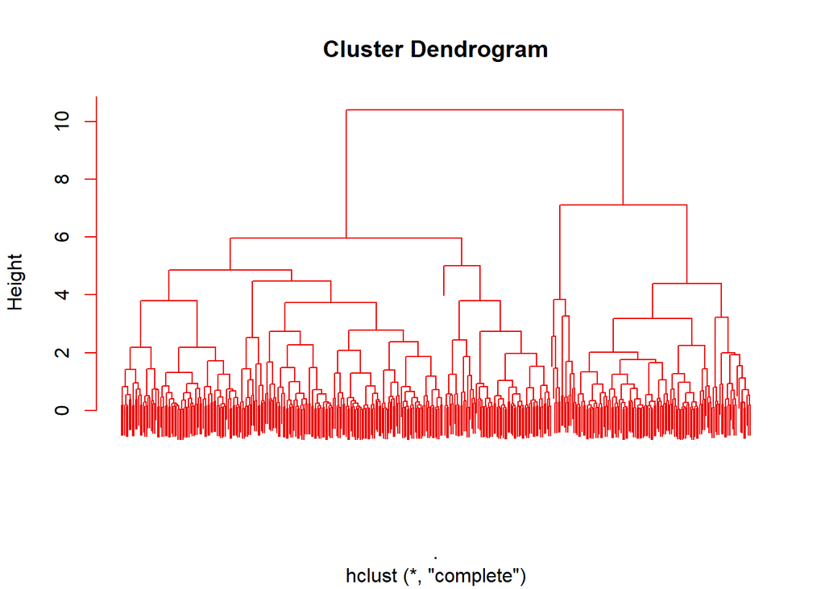

```r
hClustering<-ds.nz.col.fusion.scale[]%>%dist%>%hclust(method = "com")
plot(hClustering,col="red2",hang=0.1,labels=F)
```

Se corta el árbol y se selecciona el agrupamiento que contiene cinco clusters y posteriormente se obtiene el centroide de cada uno de los cinco clusters.

```r
clusters <- cutree(hClustering, k=5)

# Function to find medoid in cluster i (source: https://www.biostars.org/p/13143/)
clust.centroid = function(i, dat, clusters) {
    ind = (clusters == i)
    colMeans(dat[ind,])
}

ds.nz.col.fusion.unscale <- ds.nz.col.fusion %>% select(colnames(ds.nz.col.fusion.scale)) %>% mutate_all(as.numeric, na.rm=TRUE)

tmp <- sapply(unique(clusters), clust.centroid, ds.nz.col.fusion.unscale, clusters)
```

## Visualización con agrupamientos. Heatmaps.

Finalmente se va a realizar otro agrupamiento con los datos de los que se dispone, en esta ocasión un heatmap que realiza el agrupamiento tanto en filas como en columnas.

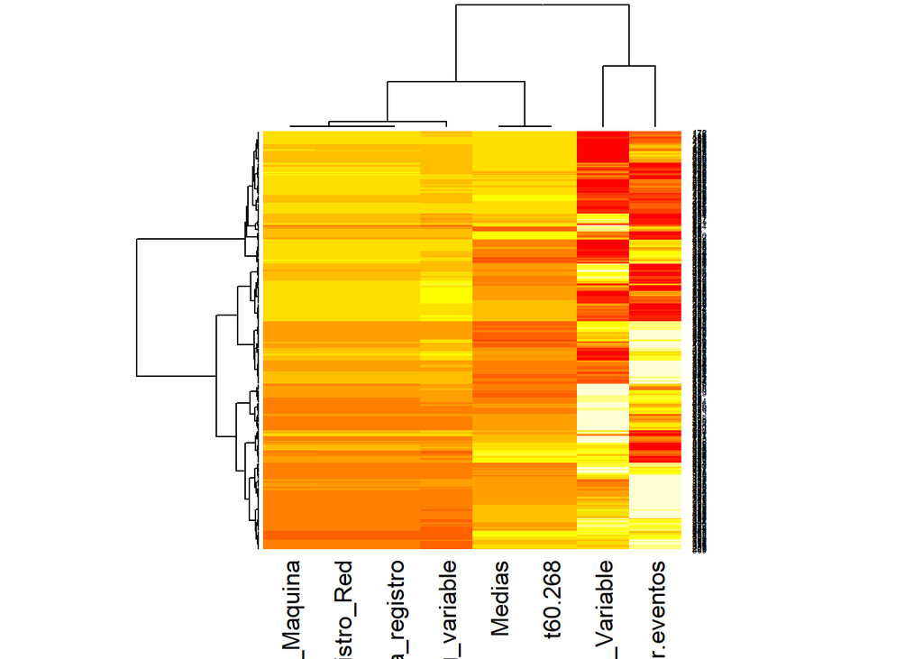

```r
dataMatrix <- data.matrix(ds.nz.col.fusion.scale)

# By column
heatmap(
  dataMatrix,cexRow=0.5,
  distfun=function(x) dist(x, method = 'euclidean'),
  hclustfun=function(x) hclust(x, method='ward.D')
)
```

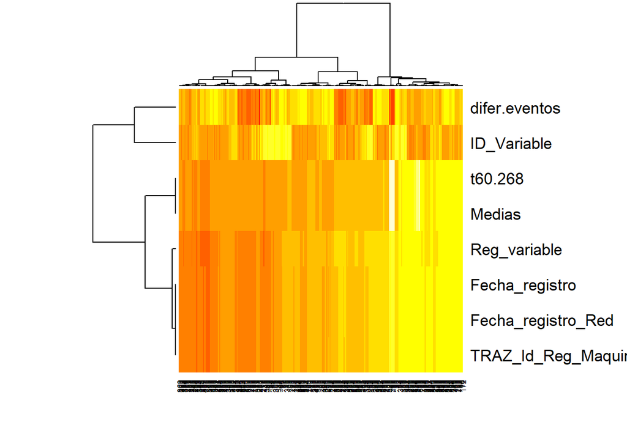

```r
# By row
heatmap(
  t(dataMatrix),
  distfun=function(x) dist(x, method = 'euclidean'),
  hclustfun=function(x) hclust(x, method='ward.D')
)
```

Las regiones del Heatmap con colores semejantes indican asociación entre las filas y las columnas, por lo tanto es una medida de las correlaciones entre las diferentes variables, al realizar a representacion por filas o columnas se obtiene lo mismo, solo que rotado. Debido a la gran cantidad de varibles representadas no es facil ver que variables estan relacionadas entre si.

# Conclusiones.

Vamos ahora a responder a las preguntas que se planteaban al comienzo de la practica.

¿Existen periodicidades? Hemos encontrado periodicidades para el fichero de los datos de funcionamiento y el fichero de averias, donde las perodicidades tienen que ver con las medidas de comprobacion de funcionamiento de los sistemas, donde se registra el parametro evaluado así como cada cuanto tiempo se registra encontrando que hay medidas que se toman cada minuto, cada 5 minutos, cada 10 minutos, cada 15 minutos y cada hora.

Para el fichero de las averias tambien encontramos diferentes periodicidades como la frecuencia de rotura o de mantenimiento que se debe realizar a la maquina con las que se esta trabajando.

¿Hay alguna relacion entre el tipo de plastico utilizado y las alarmas?

Para los plasticos más fabricados tenemos las siguientes incidencias:

El plástico con mayor numero de averias es el B1S25 G15-0008-02 con 5 averias.

¿ Existe alguna relacion entre el tipo de plastico y la duracion de los procesos ?

-Para B1S25 G15-008-02 tarda alredeor de media hora en solventarse las averias. -Para PPC1S15 G30-007-02 tarda alredor de 20 minutos las averias en solucionarse. -Para A1S25 G20B10-0020-02 tarda alredor de 22 minutos en arreglar las averias.

Los plasticos que mas tardan en solucionar sus averias son B1S25-G10M202-0005-02, B1X25 V0-9010-02 y PPC1S15 M20XV2-0072-02.